# DATA 620 Final Project: Nonprofit Graduate Course Description Analysis using NLP and SNA

## Abstract

Graduate programs in nonprofit management have expanded rapidly alongside the growth and professionalization of the nonprofit sector. Yet, prospective students and employers often lack clear information about what these programs teach or how similarly named programs differ across institutions. Although prior scholarship has raised theoretical concerns about fragmentation in nonprofit education, this study provides the first large-scale empirical examination of linguistic and topical similarity in graduate nonprofit course descriptions.

Drawing on signaling theory, information asymmetry, and catalog-based curriculum research, the study analyzes 616 core course descriptions from 60 U.S. universities offering nonprofit-focused graduate degrees or certificates. The universities are divided across five school types (Business, Public Administration, Social Sciences, Professional Studies, and Other). Using TF–IDF vectorization and cosine similarity, unigram, bigram, and trigram measures, as well as social network analysis, the analysis tests whether curricular heterogeneity exists, how it varies by school type, and how it differs by program title. Results show that course descriptions share a common conceptual foundation, evidenced by recurring core terms and themes, but exhibit substantial linguistic and structural heterogeneity in how these ideas are expressed. Low cosine similarity scores at both the unigram and bigram levels, along with network fragmentation, confirm high variability in phrasing despite thematic overlap, supporting H1a.

Variation is consistent across school types, with uniformly low similarity scores and overlapping vocabularies, supporting H1b. Additionally, although program titles are widely shared across institutions, underlying course descriptions vary considerably, supporting H1c and indicating a disconnect between program naming and curricular content.

These findings demonstrate that nonprofit education operates in a fragmented signaling environment, where programs appear similar through shared terminology but lack consistent communication of substantive differences. This contributes to information asymmetry for students and employers and underscores the need for clearer curricular standardization and signaling mechanisms in nonprofit management education.

## Introduction

Nonprofit organizations play an indispensable role in modern economies and civil societies, addressing gaps that neither markets nor governments can effectively fill (Brock, 2004). The scope of the nonprofit sector is vast, accounting for nearly ten percent of private-sector employment in the U.S. (United States Bureau of Labor Statistics, 2025a). Among private nonprofit workers aged 25 and older, 32.7% held an advanced degree or higher (United States Bureau of Labor Statistics, 2025b). This education statistic signals to those interested in the nonprofit industry that formal education is valued. But this raises a question as to what is being valued when the academic infrastructure supporting nonprofit management education has been reported as fragmented (Amey, 1992)? This invites further inquiry into the structure and content of nonprofit management education curricula.

Nonprofit programs are mainly housed in Schools of Public Administration, Schools of Business, Social Science Schools, Schools of Professional Studies, and Other Schools. Each type of school aims to frame nonprofit education differently. However, prospective students, employers, and donors must infer program quality from imperfect signals such as course descriptions, program names, school types, tuition, institutional prestige, and accreditation status, among others. This heterogeneity produces a communication problem, making it challenging to make educational decisions.

From an economic perspective, this is a textbook case of information asymmetry (Akerlof, 1970). This could be problematic, as Akerlof demonstrated that when consumers cannot distinguish between high-quality and low-quality products, markets systematically undervalue genuine quality and reward imitation. In nonprofit management education, the way programs are positioned within institutions serves as a signal, conveying perceived value, credibility, and strategic priority as inputs to calculate whether productive capability will increase and if there is sufficient return. When there are differences between a program's title and the course descriptions that make up that program, it creates information asymmetry and imperfect information.

To address the growing demand for skilled professionals in the nonprofit sector, nonprofit educational programs must be designed to prepare students for critical roles in mission-driven organizations. However, information asymmetry and signal interpretation pose a business problem when schools may not equip students with the skills employers expect. The school type, what it offers, its costs, and even its location may influence how nonprofit education is delivered to meet the needs of the nonprofit sector. Logically, interested employers seeking prospective employees with finance, accounting, and strategic management skills should look for graduates of programs housed in Schools of Business. Interested employers seeking prospective employees with ethics and governance skills should look for graduates of programs housed in Schools of Public Administration. However, with little variation in program titles, nonprofit education experiences are challenging to decipher.

## Purpose of the Research

The purpose of this research is not solely to detect linguistic heterogeneity but to demonstrate the extent of the problem: a fragmented educational marketplace that confuses students, employers, and accrediting bodies about the meaning of a “nonprofit management” degree. This study is also designed as a diagnostic stage of a longer research agenda that explores how accounting, finance, and auditing frameworks can professionalize nonprofit management education. This paper identifies programmatic structures and course descriptions between school types, and indicates how they communicate value to prospective students and employers.

## Main Research Questions

1. How do nonprofit programs vary in course descriptions?
2. How does school type affect variation in course descriptions?

## Hypotheses Development

When students explore graduate programs, they make decisions with limited information. As an experience good, they cannot directly observe classroom quality, faculty engagement, or instructional style until they enroll. Instead, they rely on signals such as program titles, course descriptions, costs, and school reputations to decide whether a program aligns with their goals. Course descriptions are curricular design, marketing, and communication, all in one. They inform prospective students about the university's values and the kind of learning experience they can expect.

Faculty, administrators, and staff members write course descriptions and select program titles through professional judgment, committee input, institutional policy, and mimicking other institutions. These choices reflect both academic intent (what faculty want students to learn), and strategic communication (how the program wants to be perceived). Over time, this process creates language that is partly educational and partly symbolic. The language serves as a bridge between what the faculty teach and what students believe they are receiving. When multiple faculty members or departments contribute to a program, their styles and emphases can diverge, resulting in inconsistencies in tone, content, and focus. These differences underlie curricular fragmentation.

Linguistic and topical variation determine how nonprofit education programs signal identity and quality to external audiences. When both are analyzed computationally, they provide a multidimensional framework for detecting fragmentation, coherence, and institutional differentiation in nonprofit curricula. When course descriptions show high variability, they indicate that nonprofit curricula are fragmented in both form and substance. Nonprofit graduate programs are structurally constrained. Regardless of the program, they tend to cover a common core, including leadership, financial management, fundraising, and governance issues. Therefore, the topics should be somewhat similar. Although topics may be similar, they can be expressed through diverse language. The foregoing discussion forms the conceptual foundation for the following hypothesis:

H1a: Course descriptions for nonprofit education programs will demonstrate low topical and high linguistic heterogeneity.

From a signaling perspective, schools borrow similar language and structure to remain competitive and appear credible to external audiences. Universities offering nonprofit management programs rely on a common set of familiar terms, such as "nonprofit", “leadership,” “management,” or “public”. These terms signal legitimacy to external audiences. This creates a shared vocabulary across course descriptions. However, similarity at the level of individual words does not imply similarity in overall meaning. Each program combines these common terms with different topics, emphases, and contextual language. As a result, even though descriptions draw from the same pool of words, they are arranged in distinct ways and paired with different concepts. This produces low cosine similarity and high distinctiveness. Course descriptions overlap in vocabulary, but differ substantially in how that vocabulary is used. In other words, the words may sound familiar, yet remain meaningfully dissimilar when analyzed as complete texts. Fragmentation is adopted by other schools and is not unique to any one type of school. Fragmentation becomes a feature of the broader field of nonprofit education. Therefore, variation is expected across all schools, but its overall magnitude should not differ significantly. This leads to the following hypothesis:

H1b: Course descriptions for nonprofit education programs will demonstrate similar topical and linguistic heterogeneity levels across school types.

Program titles, such as Nonprofit Management, Nonprofit Leadership, or Nonprofit Administration, serve as deliberate identity signals. Faculty and other decision-makers select these names more carefully than course descriptions to communicate the program’s core purpose and target audience. Each program title carries a different meaning. For example, Nonprofit Management may intend to emphasize efficiency, planning, and operations, Nonprofit Leadership may intend to emphasize influence, interpersonal skills, and personal development, and Nonprofit Administration may intend to emphasize governance, policy, and accountability. Students use these program names to interpret what kind of learning experience they will receive. Because each title attracts a different type of student and reflects a different professional logic, it is reasonable to expect greater linguistic and topical variation across program titles than across school types. This leads to the following hypothesis:

H1c: Course descriptions for nonprofit education programs will demonstrate low topical and high linguistic heterogeneity in program names.

## Research Design

This is a mixed-method qualitative and quantitative study. Data is processed in Python (version 3.13.9), using Jupyter Notebook (version 7.4.5). This analysis requires very complex coding. AI tools are used to assist in the more complex coding. All other guidance is primarily sourced from my originally developed dataset, from Natural Language Toolkit, and Tsvetovat & Kouznetsov (2011). During the Spring/Summer 2025, and Spring 2026 semesters, I manually extracted (copied and pasted into an Excel file) nonprofit graduate-level curricula from publicly accessible web catalogs of 60 U.S. educational institutions offering master’s degrees or certificates in nonprofit education. The educational institutions were identified from the College Navigator website and an internet search of nonprofit curriculum offerings. Each educational institution’s catalog and website were examined. For the purposes of the current research, the collected data included university names, school names, program titles, core versus elective status, and course descriptions. The data was initially recorded in a CSV file in Excel. Feature engineering was employed to create a new variable, “school_type,” and, upon review of the school websites, each school was categorized into one of five school types: Public Administration (PA), Business (B), Social Sciences (S), School of Professional Studies (PS), or Other (O). The dataset currently resides in my GitHub account. AI-assisted tools (ChatGPT) were used to support coding and text refinement. All outputs were reviewed and validated.

I divided the project into modules, as outlined below.

Module 1: Data Setup: List of Libraries Used in this Research.  
Module 2: Data Preparation: Load Data.  
Module 3: Data Structuring: Subset Columns.  
Module 4: Exploratory Data Analysis on Variables.  
Module 5: NLTK Analysis.  
Module 6: Unigram TF–IDF and Cosine Similarity.  
Module 7: Bigram TF-IDF and Cosine Matrix.  
Module 8: Linguistic Signal Analysis by School Type.  
Module 9: Social Network Analysis: Network Filtering via thresholds.  
Module 10: Social Network Analysis: Centrality Measures.  
Module 11: Social Network Analysis: Community Detection.

## Results and Discussion of Modules

The modular analysis provides converging evidence that nonprofit graduate curricula exhibit conceptual convergence and linguistic fragmentation, with important implications for signaling, differentiation, and information asymmetry.

**Modules 1–4** cover the structural setup, data import from my GitHub account, data preparation, and structural validation. The original dataset had 22 variables, of which many were not used in this research. Therefore, I subsetted the dataframe to include only the variables of interest. I further subsetted to just core courses and had foregone electives. The rationale for using only core courses is that all students in a program must take them and be exposed to the same general material. Although elective courses are important, they may not provide a uniform experience among students within a program, and leave them for future research. I created a backup copy of the dataset before any transformations. The data was then standardized through text normalization steps, including converting all descriptions to lowercase and removing extraneous whitespace. Deduplication logic was applied. Rows were removed only when they represented exact duplicates within the same university (unitid), program, and course name. This process reduced the dataset from 617 to 616 rows, confirming that only one redundant entry existed. At the same time, 25 duplicate descriptions were intentionally retained, as they represented meaningful reuse across different programs or institutions rather than errors.

In **Module Five (5)**, I began the NLTK Analysis. I removed stopwords obtained from the NLTK library and my own domain-specific word list. The total number of unique stopwords removed from the dataset is 198. I then tokenized the corpus, removed truncated words (a byproduct of copying and pasting from website course descriptions into Excel), and converted them into lists. I then merged all the word lists into a single large list. The total words = 17,385 across 616 documents.

Further inquiry involved a word frequency analysis, specifically a unigram, bigram, and trigram. The **unigram analysis** showed how often each word appeared across all course descriptions. In a graph, I show the 20 most frequently used words. The five most frequently used words across course descriptions are **“nonprofit”** (484 occurrences), **"course"** (408), **“organizations”** (306), **"students"** (252), and **“management”** (250), indicating a strong emphasis on organizations in nonprofit management and the use of academic structural language such as "course" and "students".

A **bigram analysis** identified frequently used word pairs. The phrase **"nonprofit organizations"** dominated with 168 appearances, followed by **"nonprofit sector"** (43), **"course provides"** (36), and **"public administration"** (35) times. The bigram analysis revealed the presence of "filler" words, which are generic or non-informative in a course description. I set up code to potentially remove them iteratively until I can be satisfied that no significant filler phrases remain in the analysis.

A **trigram analysis** identified and captured more context-dependent phrases that make sense only in a specific context. The trigram analysis revealed some meaningful and more filler three-word phrases. The possible meaningful phrases include **"human resource management,"** (12) **“public nonprofit organizations,”** (12) and **“certificate nonprofit management,”** (12) indicating an emphasis on organizational management, workforce administration, and academic credentials within the nonprofit sector. In the data, phrases like **“topics covered include”** and **“offers opportunity learn”** also appear, which suggest standardized course description language.

To further analyze the words, I used POS Tagging focused on grammatical roles (noun, verb, etc.) to contextually examine how important words are actually used in sentences and whether they are being discussed as ideas or as actions. Over **56% of all words are nouns**, focused on ideas and concepts. In contrast, only about **18.6% are verbs**, suggesting the courses are described more like academic subjects rather than what students will actually do. **Adjectives make up about 21.4%** of the language, adding descriptive detail, but much of the structure still follows repetitive patterns that make programs sound similar. *Overall, the surprising takeaway is that these programs emphasize what is taught more than how students will apply it.*

After POS Tagging, I analyzed word co-occurrence. I selected a small set of keywords from the course descriptions: **nonprofit**, **management**, **public**, and **business**. I extracted a small window of surrounding words (two before and two after). The resulting phrases are short token-based fragments that illustrate how each word is used. The results indicate that the word *"nonprofit" appears primarily in the context of organizations and management.* The phrases seem to focus more on real-world organizational structures and not abstract ideas. The word *"management" appears primarily as a connector across various areas of management.* The phrases seem to focus more on people, functions, and systems. The word *"public" appears to be used primarily in the context of government and policy.* The phrases seem to focus more on a strong connection to the public sector. *The word "business" appears to be used primarily as a descriptor.* The phrases seem to focus more on nonprofit programs relative to business education, not as the focus.

In **Module Six (6)**, I shift the analysis to quantify the course descriptions by conducting unigram TF–IDF and cosine similarity analyses. Term Frequency (TF) - Inverse Document Frequency (IDF) assigns a weight to each term within a document based on how informative it is. TF is how often a term appears in a document, and IDF down-weights terms that appear in many documents. A high score means a term is important or distinctive for a document. A low score means a term is common or less important. I analyzed the entire corpus as a single dataset by converting the cleaned text into TF–IDF scores (term importance in documents) to identify the most distinctive terms. I computed unigram cosine similarity between course descriptions, which measures how similar or standardized the language is across all programs. Cosine similarity compares the TF-IDF weights on a scale from 0 to 1. The closer to one, the more similar a course description. Effectively, this part of the research quantifies linguistic distinctiveness and similarity across course descriptions to establish a systematic baseline for assessing variation and standardization.

I analyzed 616 course descriptions across 1,482 terms. The language in the course descriptions is concentrated around a relatively small set of core ideas. The most distinctive terms are **"nonprofit (0.052)," "public (0.043)," "management (0.042)," "course ( 0.040), and "financial" (0.036). They indicate that programs are primarily focused on managing nonprofit organizations within a broader public and social context. The prominence of words like "course," "students," "covers," and "examines" indicates that a significant portion of the language is generic and instructional rather than highly specialized. There are non-generic terms such as "strategies," "planning," "fundraising," and "development", which indicate references to applied skills in the course descriptions. The overall pattern reflects a strong emphasis on conceptual structure and standardized phrasing. The mean TF-IDF scores were low (example: "nonprofit" = 0.052 - the most important term), indicating that course descriptions are largely consistent across programs and show limited differentiation in how content is presented. Note that the scores are not read as percentages, but rather as a ranking. The reported low standard deviation of 0.08 for the word "nonprofit" indicates that words appear similarly across course descriptions.

After quantifying the importance of terms, I computed cosine similarity to show how similar each course description is to the others. The 616 × 616 matrix means every course is compared with all others. The average similarity of 0.039 is very low, indicating that most descriptions differ significantly in their exact wording. A maximum similarity score of 1.0 likely reflects duplicate course descriptions across programs within the same institution. A minimum score of zero reflects total dissimilarity.

In **Module Seven (7)**, I examined bigram TF–IDF and Cosine Similarity analyses. The analysis to this point has focused on unigrams in the overall corpus. However, unigrams are useful for revealing shared isolated words, but lack the rigor that shared phrases could potentially reveal. The bigram analyses identified the most distinctive two-word phrases across the entire corpus. Bigrams may reveal concept-level language rather than isolated words. Each score represents the mean TF–IDF weight of that phrase across all documents. *The results show a strong concentration around three thematic clusters.* First, the phrases “nonprofit sector,” “public administration,” “public sector,” and “nonprofit management” suggest that the dataset is more focused on nonprofit and government-oriented programs. Second, there is a management and organizational theme surfacing, reflected in phrases such as “financial management,” “strategic planning,” and “human resource.” These suggest that programs emphasize business. Third, there is a mix of instructional and academic language, including “course provides,” “students learn,” “capstone course,” and “research methods.” These are more filler phrases, discussed earlier. They reflect common academic framing rather than domain-specific differentiation.

A bigram cosine similarity analysis showed that at the phrase level across individual course descriptions, they are not similar. The average cosine similarity of 0.006 indicates that course descriptions rarely use the same two-word combinations. In other words, while programs may consistently discuss similar topics such as nonprofit management or public sector work, but they tend to express these ideas using different phrasing, resulting in minimal overlap in bigrams. These results indicate that the dataset is conceptually cohesive but linguistically heterogeneous.

A bigram similarity network showed 616 nodes and 10,437 edges (connections) where institutions share some level of phrase-level similarity. The network is not nearly as dense as the unigram network, meaning many institutions share much less overlapping bigram language in their course descriptions. This suggests that while institutions may differ in specific phrasing, there is still an underlying similarity in how course descriptions are constructed, with recurring phrases appearing across many schools. The fact that the network is not fully dense implies that bigrams are capturing more specific and distinguishing language patterns, which should lead to clearer clustering once weaker edges are filtered out. Like the Unigram Network discussion in Module 6C, applying a threshold will eliminate weak ties.

**Module 8** introduces a structured comparison of course descriptions across school types, building on prior evidence that program titles explain very little of the variation in language, as heterogeneity largely occurs within categories. School types are divided by Public Administration (PA), Business (B), Social Sciences (S), Professional Studies (PS), and Other (O). I identified, visualized, and listed universities by school types. I conducted unigram and bigram between-group comparisons. Descriptive results show that PA represents the largest group with 248 observations, B with 191 observations, S and PS, each with 67 observations, while O is the least represented, with 43 observations. Overall, the distribution is uneven, with PA and B comprising the majority of the dataset, while the remaining groups make up a smaller proportion. I included a table to view which universities are in the groupings.

I analyzed Unigram TF–IDF Distinctiveness and Cosine Similarity Between School Types. I identified the most distinctive vocabulary for each school type, computed the mean TF–IDF score for each term in that group, and selected the top 10 highest-scoring terms. terms like “nonprofit,” “management,” and “course” appear across multiple columns as one of the highest three-ranked words. The PA group is strongly associated with “public” (0.072) and “nonprofit” (0.052), which aligns with a public administration focus. PS includes terms like “nonprofit” (0.064), “management” (0.040), and “social” (0.039), suggesting a mix of administrative and social-sector themes. The S group appears to emphasize "nonprofit" (0.052), “course” (0.052) and “organizations” (0.044), pointing toward structural or curricular language rather than domain-specific terminology. The B group shows terms like “nonprofit” (0.049), “course” (0.045), and “management” (0.037), indicating overlap with other groups but with less dominance of any single theme. This overlap, especially around “nonprofit,” “management,” and “course”, suggests shared vocabulary across programs, which may reduce how sharply the groups are separated. Overall, the matrix indicates that S is the most specialized group, O is the most general, and the remaining groups (B, PA, PS) share overlapping terminology with moderate differentiation driven by domain-specific keywords like “public,” “nonprofit,” and “management.”

The results of the Unigram Cosine Similarity Between School Types indicate that course descriptions are highly diverse in their language across all groups. Similarity values are uniformly low, ranging from approximately 0.033 to 0.053, consistent with the overall document-level average and suggesting that most course descriptions share little exact wording. For example, Public Administration (0.044) is only marginally more similar to Business (0.040) or Other programs (0.041). This suggests weak linguistic differentiation across school types. Overall, the findings suggest that while programs share a common baseline vocabulary, the way this language is used varies considerably, limiting the extent to which group membership can be inferred from textual content alone. Phrases like “nonprofit organizations,” “public administration,” and “financial management” appear across multiple columns, indicating common thematic overlap, while other phrases (e.g., “students learn,” “capstone course,” or “strategic planning”) reflect more specialized emphases within particular school types.

I also analyzed Bigram Cosine Similarity Between School Types. The bigram analysis indicates that while school types share a common conceptual foundation, they differ in how that language is emphasized and structured. Core phrases such as “nonprofit organizations,” “public administration,” and “financial management” rank among the top bigrams across groups, with mean TF–IDF values typically ranging from approximately (0.008 to 0.017), indicating consistent importance across the corpus. However, relatively high standard deviations (0.05–0.08) for many of these phrases suggest uneven distribution, meaning they are emphasized more strongly in some programs than others. Pairwise comparisons further show substantial overlap in top-ranked bigrams, particularly between groups such as PA and B, reinforcing a shared conceptual vocabulary. Despite this overlap, cosine similarity scores based on bigram TF–IDF are uniformly very low (approximately 0.002–0.007), with minimal variation between group pairs, indicating that programs rarely use the same two-word phrases in similar ways. The distribution of similarity values, which clusters near zero across all groups, supports this finding. Overall, these results suggest that although programs draw from a shared set of core concepts, differences in phrase-level usage produce weak linguistic similarity across school types.

**Module 9** examines a network analysis that adjusts similarity thresholds to reveal how linguistic relationships shift from broad overlap to meaningful separation. The network analysis provides confirmation of these patterns discovered in earlier modules. I calculated the threshold level where the unigram breaks into more than one component, which is 0.1495. I then created a table setting different thresholds at 5%, 10%, 14.95%, 20%, and 40% to illustrate components at different levels. The global unigram threshold at 0.05 still produces a highly connected network (616 nodes, 53,641 edges, 28% density) with a single component, showing that institutions share a widely distributed vocabulary. At 0.10 is still one component. At 0.20, it breaks into 7 components. The bigram threshold at 0.05 is still a single component, but it yields a sparser network (610 nodes, 5,214 edges, 2.8% density), which is then split into two components. This may suggest that shared phrases are far less common. I created a network visualization that shows this contrast. The unigram networks appear as dense, cohesive clusters, while bigram networks are more dispersed, with emerging gaps and smaller groupings. As I increase the unigram threshold to 0.10, the unigram network remains fully connected, but the bigram network fragments into 6 components; by 0.20, this expands to 7 components for unigrams versus 37 for bigrams; and at 0.40, the bigram network breaks into 100 components, revealing highly localized clusters of similarity. Module 9D visually shows this fragmentation, with nodes separating into distinct clusters as weaker ties disappear. Shifting to the group level in Modules 9E–9H, the same pattern persists but becomes even more pronounced. At low thresholds (0.02–0.03), all groups are weakly connected (10 edges), but at 0.04, only 3 edges remain, leaving some groups isolated. Correspondingly, group-level cosine similarities are extremely low (0.002–0.003), indicating minimal shared phrasing across school types. Together, these modules show a clear progression: while general vocabulary creates a densely connected structure, increasing specificity at the phrase level rapidly exposes fragmentation, revealing that linguistic similarity across institutions and groups is weak and not structurally cohesive.

**Module 10** examines four centrality measures: degree, closeness, betweenness, and eigenvector, to evaluate how linguistic similarity structures differ between unigram and bigram networks. The results reveal a consistent contrast in the two networks between a dense, homogeneous structure and a sparser, more differentiated network.

In the unigram network, centrality values are uniformly high across all measures, indicating widespread connectivity and minimal differentiation. Degree centrality ranges from 0.56–0.63, showing that most course descriptions are directly connected to a large proportion of others, reflecting extensive overlap in shared vocabulary. Closeness centrality is similarly high (0.69–0.73), indicating that nodes occupy central positions within a tightly integrated network and can reach others through very short paths. Betweenness centrality remains low and relatively uniform (0.004–0.006), suggesting that no nodes play a significant intermediary role. The large amount of redundant connections reduces the need for structural bridges, reinforcing the interpretation of a highly cohesive network. Eigenvector centrality is modest but tightly clustered (0.073–0.084), indicating that influence is evenly distributed across nodes. Because most course descriptions are connected to other highly connected nodes, no single program emerges as structurally dominant. Together, these measures characterize the unigram network as a dense and non-hierarchical network, where similarity is broad, diffuse, and largely undifferentiated.

In the bigram network, centrality values are substantially lower and more variable, indicating a shift toward structural differentiation. Degree centrality drops sharply (0.076–0.091), showing that nodes are directly connected to far fewer others, reflecting limited overlap in phrase-level language. Closeness centrality is also lower (0.43–0.44), indicating greater distance between nodes and a less compact network structure. Betweenness centrality is higher and more variable (0.014–0.023), suggesting that certain nodes act as key bridges connecting otherwise disconnected clusters. These nodes occupy structurally important intermediary positions, linking distinct thematic areas within the dataset. Eigenvector centrality is also more unevenly distributed (0.137–0.167), with a subset of nodes emerging as more influential due to their connections to other highly central nodes. This indicates the presence of a core-periphery structure, in which influence is concentrated among programs that employ widely shared, structurally significant phrase-level combinations, while others remain more peripheral.

Visually, these differences are reflected in network structure: the unigram network forms a dense “hairball,” characterized by extensive overlap and limited separation, whereas the bigram network is sparser, with visible hubs, bridges, and isolated clusters.

Taken together, the centrality measures demonstrate that unigram networks capture broad, generalized similarity, making most programs appear equally central, while bigram networks reveal more selective and meaningful relationships, highlighting fewer but more structurally influential nodes. Unigram centrality reflects commonly used, standardized language across nonprofit programs, whereas bigram centrality identifies where distinctiveness, influence, and thematic integration emerge. These findings indicate that while nonprofit curricula share a common linguistic foundation, meaningful differentiation occurs only at higher levels of linguistic specificity. Influence and structural importance are not evenly distributed across programs but are instead localized within a subset of nodes, supporting the conclusion that differentiation in nonprofit education is fragmented and uneven rather than systemic.

**Module 11** examines community detection. The results highlight a critical distinction between broad visibility and meaningful differentiation in nonprofit program positioning. The unigram network produces only 2–3 large, overlapping communities (with two dominant clusters), indicating that most programs cluster and rely on a shared, generalized vocabulary that makes them appear similar. From a strategic perspective, this may suggest that simply using common terms like “nonprofit management” or “social impact” will not meaningfully distinguish a program in a crowded market. In contrast, the bigram network reveals 14 smaller communities, each defined by more specific thematic language such as fundraising, strategic planning, public policy, or financial management. This structure indicates that distinctiveness arises from specific combinations of concepts rather than from individual terms.

However, similar topics fragment into separate clusters due to minor phrasing differences, suggesting that programs lack standardized ways of communicating similar content. As a result, even substantively similar curricula may appear distinct, exacerbating information asymmetry.

Programs that rely on generic language will blend into the large, dense core of the network, making them harder for prospective students to distinguish. In contrast, programs that consistently emphasize specific thematic combinations, such as “grant writing and fundraising,” “public policy and research methods,” or “financial planning and reporting”, are more likely to occupy distinct positions. However, the bigram network produces fragmentation at the margins, where similar financial topics split into multiple small clusters due to minor phrasing differences.

*Taken together, the results of the analysis in **modules 1-11** provide empirical support for all three hypotheses:*

**H1a (Heterogeneity): Supported.** Course descriptions exhibit clear linguistic and structural heterogeneity, particularly at the phrase level, despite sharing a common conceptual foundation.

**H1b (Similarity across school types): Supported.** Variation is consistent across institutional categories, with no meaningful differences in the magnitude of heterogeneity between school types.

**H1c (Variation by program title): Supported.** The widespread reuse of program titles, combined with substantial variation in underlying descriptions, demonstrates that titles function as weak and potentially misleading signals of curricular content.

## Limitations

Several limitations may affect the analysis. Although catalogs advertise course descriptions, faculty members may deviate in the syllabi. Education is an experience good and can only be truly evaluated after the good is consumed. NLP methods capture patterns but do not fully explain causality, meaning results will be descriptive rather than definitive. Although I took great care in developing the dataset, variation in data completeness or formatting may introduce bias.

## Theoretical and Practical Implications

From a signaling theory perspective, the findings reveal a decoupling between signal form and signal content. Programs converge on similar labels and core vocabulary to maintain legitimacy, yet diverge in how they articulate substance. This produces a market in which signals are abundant but not discriminative, increasing information asymmetry for students and employers.

From an institutional perspective, the results suggest that nonprofit education has evolved through mimetic processes, adopting shared language without achieving standardization in meaning. The consequence is a fragmented educational marketplace in which apparent similarities mask underlying inconsistencies.

Overall, the evidence indicates that nonprofit graduate education is not lacking in content. It is the coherent, consistent communication of that content that limits the effectiveness of course descriptions as signals of program quality and differentiation.

## Module 1: List of Libraries Used in this Research

In this module, I provide a list of libraries used to conduct this research. The libraries are repeated inside the subsequent modules so the reader can understand when and how they are used. The libraries give insight to how the analytical approach is framed as a structured NLP and SNA workflow.

```python
# Module 1: List of all unique libraries and submodules used in this research

# Core data handling
import pandas as pd
import numpy as np

# Text processing/NLP
import re
import nltk
from nltk.tokenize import word_tokenize
from nltk.corpus import stopwords
from nltk.util import ngrams
from nltk.util import bigrams
from nltk.util import trigrams

# Feature extraction/modeling
from sklearn.feature_extraction.text import TfidfVectorizer
from sklearn.metrics.pairwise import cosine_similarity

# Network analysis
import networkx as nx

# Visualization
import matplotlib.pyplot as plt
import seaborn as sns

# Statistical analysis
from scipy.stats import ttest_ind

# Utility libraries
from collections import Counter
import itertools
import warnings
warnings.filterwarnings('ignore')
```

## Module 2: Load Data

The data resides in a GitHub repository and imported directly into this research.

```python
# Module 2: Load data
df = pd.read_csv("https://raw.githubusercontent.com/professorfoy/data620/refs/heads/main/final-project/Master_Programs_Grad.csv")

# Clean column names
df.columns = df.columns.str.strip().str.lower().str.replace(" ", "_")

print(df.columns.tolist())
```

```
['university', 'unitid', 'addr', 'city', 'state', 'zip', 'location', 'latitude', 'longitude', 'school_name', 'school_type', 'program_title', 'specialization', 'program_type', 'in_state_tuition_yearly', 'out_state_tuition_yearly', 'in_state_tuition_course', 'out_state_tuition_course', 'in_state_fees'…
```

## Module 3: Subset Columns

The original data set has 22 variables, many which are not used in this research. Therefore, this module subsets the dataframe with just the variables of interest.

```python
## Module 3: Subset Columns

import pandas as pd

COLS = [
    'university', 'unitid',
    # 'addr', 'city', 'state', 'zip', 'location',
    # 'latitude', 'longitude', 'school_name',
    'school_type', 'program_title', 'in_state_tuition_course',
    # 'out_state_tuition_course','program_type', 'tot_cr_hrs', 'req_crs', 'elect_crs', 'course_code',
    'course_name', 'core_elec', 'course_desc'
]

# Subset columns immediately after loading
df = df[COLS].copy()

# Filter to only core_elec = 'C'
df = df[df['core_elec'] == 'C'].copy()
```

## Module 4: Exploratory Data Analysis on Variables

This module checks the structure of the data that there are no missing values, and then looks for patterns, such as repeated course descriptions. The dataset has 617 core course descriptions from 60 different universities. There are 8 variables. The in_state_tuition_course variable needed to be converted from an object to a numeric variable. I also inspected for missing values and found none. The in_state_tuition_course variable is retained in the data set for future analysis.

I identify when the same course content appears multiple times across different programs or universities. Instead of immediately removing those duplicates, I created code to see where the course duplicates occur and how they occur. This is important because those course duplicates are not necessarily errors. They may represent meaningful relationships, like shared curriculum across programs. In this module, I save a clean copy of the original dataset, in case I need to backtrack if something goes wrong in the analyses.

```python
# Module 4A: Characteristic Analyses on Variables

print(df.info())

# Total unique universities
unique_universities = df['university'].nunique()

print(f"\nTotal Unique Universities: {unique_universities}")
```

```
<class 'pandas.core.frame.DataFrame'>
Index: 617 entries, 0 to 1114
Data columns (total 8 columns):
 #   Column                   Non-Null Count  Dtype
---  ------                   --------------  -----
 0   university               617 non-null    object
 1   unitid                   617 non-null    int64
 2   school_type              617 non-null    object
 3   program_title            617 non-null    object
 4   in_state_tuition_course  617 non-null    object
 5   course_name              617 non-null    object
 6   core_elec                617 non-null    object
 7   course_desc              617 non-null    object
dtypes: int64(1), object(7)
memory usage: 43.4+ KB
None

Total Unique Universities: 60
```

```python
# Convert the in_state_tuition_course to numeric

df['in_state_tuition_course'] = pd.to_numeric(
    df['in_state_tuition_course']
        .str.replace(',', '', regex=False),
    errors='coerce'
)
```

```python
# Module 4B: Inspect possible Missing Values
df.isnull().sum()
```

```
university                 0
unitid                     0
school_type                0
program_title              0
in_state_tuition_course    0
course_name                0
core_elec                  0
course_desc                0
dtype: int64
```

#### Module 4C: Identify Duplicate Courses

This module scans all course descriptions and counts how many times each one appears. It keeps only the descriptions that show up more than once, helping me find courses that are repeated across programs or schools. In simple terms, I am trying to find out which course descriptions are being reused. The result is that 26 course descriptions appear multiple times in my dataset.

```python
# Module 4C: Identify Duplicate Courses
dup_counts = df['course_desc'].value_counts()

# I keep only duplicated descriptions
dup_course_desc = dup_counts[dup_counts > 1]

# Get the actual number of courses duplicated
print(f"Number of duplicated course_desc: {len(dup_course_desc)}")
```

```
Number of duplicated course_desc: 26
```

#### Module 4D: Inspect Where Duplicates Occur

This module shows exactly where duplicate courses occur, listing the university, program, and course name for each one. This module allows me to see the same courses being offered in different programs within the same university or across different universities.

```python
# Module 4D: Inspect where duplicates occur

dup_rows = df[df['course_desc'].isin(dup_course_desc.index)]

dup_rows[['university','program_title', 'course_name', 'course_desc']].sort_values('course_desc').head(5)
```

|  | university | program_title | course_name | course_desc |
| --- | --- | --- | --- | --- |
| 947 | Grand Valley State University | Philanthropy and Nonprofit Leadership | Philanthropy and the Nonprofit Sector: History... | A comprehensive survey of philanthropic tradit... |
| 963 | Grand Valley State University | Graduate Certificate in Nonprofit Leadership | Philanthropy and the Nonprofit Sector: History... | A comprehensive survey of philanthropic tradit... |
| 872 | University of Notre Dame | Nonprofit Administration | Accounting | Accounting principles and practices are presen... |
| 845 | University of Notre Dame | Executive Master of Nonprofit Administration | Accounting | Accounting principles and practices are presen... |
| 1011 | Metropolitan State University | Public and Nonprofit Administration | Financial Management in Nonprofit and Public O... | Covers budgeting, fundraising, grant managemen... |

#### Module 4E: Preserve Original Dataset

This module creates a backup copy of my data before any changes are made. It also gives me the size of the dataset (617 rows) before further changes.

```python
# Module 4E: Preserve original dataset

df_original = df.copy()

print("Original shape:", df.shape)

# Define a subset for later use, but it is not applied just yet
subset_cols = ['course_desc']
```

```
Original shape: (617, 8)
```

#### Module 4F: Deduplicate Courses

This module simplifies the dataset by removing unnecessary repetition, standardizes the text by removing extra spaces, making everything work lowercase, removing exact duplicate rows, removing courses that have the same name and description, keeping only one version, and resetting the row numbering, and shows the new dataset size. The result shows only 25 duplicate descriptions remain, reducing the dataset from 617 to 616 rows. The means that one (1) row was removed because it was a duplicate or repeated entry within the same program/school and got removed, leaving 25 meaningful duplicates.

In summary, the deduplication process removes duplicate course descriptions in the SAME school, SAME program, but keeps duplicate courses in the SAME school, but a DIFFERENT program, or in a DIFFERENT school, or one with the SAME description, but a DIFFERENT course name. In other words, I am removing repeated courses only when they occur within the same unitid, school, same program, and course name. This structure allows me to analyze how similar course content is offered across programs within the same school as well as across different institutions.

```python
# Module 4F: Deduplicate courses

# Standardize text before deduplication
df['course_desc'] = df['course_desc'].str.strip().str.lower()
df['program_title'] = df['program_title'].str.strip().str.lower()
df['course_name'] = df['course_name'].str.strip().str.lower()

# Remove exact duplicates
df = df.drop_duplicates()

# Remove duplicates based on course meaning
df = df.drop_duplicates(subset=['unitid', 'program_title', 'course_name', 'course_desc'])

# Check duplicates after cleaning
print("Remaining duplicate descriptions:", df['course_desc'].duplicated().sum())

# Reset index
df = df.reset_index(drop=True)

print("Shape after deduplication:", df.shape)
```

```
Remaining duplicate descriptions: 25
Shape after deduplication: (616, 8)
```

#### Module 4G: Identify shared course descriptions within the same university

What this module does is groups data by university (unitid) and course description, then counts how many programs use that course description, and keeps only those used in multiple programs. There are 14 such courses.

```python
# Module 4G: Identify shared course descriptions within the same university

# Count how many programs share each course_desc within each university
shared_courses = df.groupby(['university', 'unitid', 'course_desc'])['program_title'] \
    .nunique() \
    .reset_index(name='num_programs')

# I keep only those used in multiple programs within SAME university
shared_courses = shared_courses[shared_courses['num_programs'] > 1]

# I keep only rows that match valid within-university duplicates
df_within_uni = df.merge(
    shared_courses[['unitid', 'course_desc']],
    on=['unitid', 'course_desc'],
    how='inner'
)

# Verify the result
print("Remaining unique shared courses:",
      df_within_uni[['unitid','course_desc']].drop_duplicates().shape[0])
```

```
Remaining unique shared courses: 14
```

#### Module 4H: Shared Course Descriptions Across Programs Within the Same University

This table shows course descriptions that are used in more than one program within the same university. For example, the course description "from the perspective of a nonprofit leader…" appears across two different programs within Johns Hopkins University.

```python
# Module 4H: Shared Course Descriptions Across Programs Within the Same University

df_within_uni[['university','program_title','course_desc']] \
    .sort_values(['university','course_desc']) \
    .head(20)
```

|  | university | program_title | course_desc |
| --- | --- | --- | --- |
| 3 | Johns Hopkins University | communication and certificate in nonprofit man... | from the perspective of a nonprofit leader, th... |
| 6 | Johns Hopkins University | museum studies and certificate in nonprofit ma... | from the perspective of a nonprofit leader, th... |
| 2 | Johns Hopkins University | communication and certificate in nonprofit man... | nonprofit governance & executive leadership: s... |
| 5 | Johns Hopkins University | museum studies and certificate in nonprofit ma... | nonprofit governance & executive leadership: s... |
| 1 | Johns Hopkins University | communication and certificate in nonprofit man... | the goal of this course is to convey the histo... |
| 4 | Johns Hopkins University | nonprofit management | the goal of this course is to convey the histo... |
| 0 | Johns Hopkins University | communication and certificate in nonprofit man... | the goal of this course is to prepare future n... |
| 7 | Johns Hopkins University | museum studies and certificate in nonprofit ma... | the goal of this course is to prepare future n... |
| 8 | University of Notre Dame | executive master of nonprofit administration | accounting principles and practices are presen... |
| 24 | University of Notre Dame | nonprofit administration | accounting principles and practices are presen... |
| 15 | University of Notre Dame | executive master of nonprofit administration | proceeding from a discussion of various theori... |
| 22 | University of Notre Dame | nonprofit administration | proceeding from a discussion of various theori... |
| 16 | University of Notre Dame | executive master of nonprofit administration | the course provides the basic concepts of the ... |
| 26 | University of Notre Dame | nonprofit administration | the course provides the basic concepts of the ... |
| 10 | University of Notre Dame | executive master of nonprofit administration | the focus of this course is on developing stud... |
| 18 | University of Notre Dame | nonprofit administration | the focus of this course is on developing stud... |
| 17 | University of Notre Dame | executive master of nonprofit administration | this course discusses the marketing needs and ... |
| 23 | University of Notre Dame | nonprofit administration | this course discusses the marketing needs and ... |
| 12 | University of Notre Dame | executive master of nonprofit administration | this course examines a range of ethical issues... |
| 19 | University of Notre Dame | nonprofit administration | this course examines a range of ethical issues... |

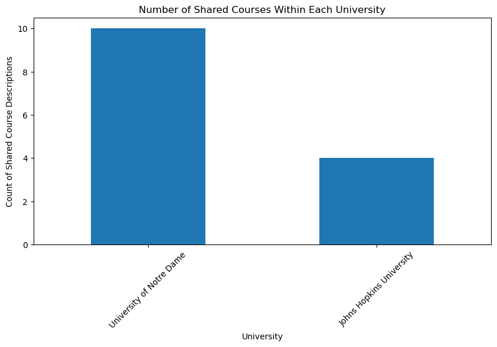

```python
dup_counts = shared_courses.groupby('university').size().sort_values(ascending=False)

dup_counts.plot(kind='bar', figsize=(10,5))
plt.title("Number of Shared Courses Within Each University")
plt.ylabel("Count of Shared Course Descriptions")
plt.xlabel("University")
plt.xticks(rotation=45)
plt.show()
```

## Module 5: NLTK Analysis

#### Module 5A: Load libraries

```python
# Module 5A: Load libraries

from nltk.util import bigrams
from nltk.util import trigrams
import nltk
from nltk.tokenize import word_tokenize
from nltk.corpus import stopwords
from nltk.util import ngrams
from collections import Counter
```

#### Module 5B: Download stopwords

In this module, I downloaded stopwords. The NLTK library contains a tokenizer (“punkt”) and a predefined list of English stopwords. The standard English stopwords include common words such as “the,” “and,” and “is”. These words appear frequently but do not carry meaningful analytical value.

I also included a list of domain-specific stopwords. These are words that may be common within course descriptions, such as “course,” “students,” or “introduction.” In the analysis, I currently commented out the domain-specific stopwords (in effect, placeholders) to include them if needed. The base stopwords and any domain-specific terms are then combined into a single set, creating a comprehensive list of words to exclude from analysis. The total number of stopwords removed from the dataset is 198.

```python
# Module 5B: Download stopwords

for pkg in ['punkt', 'punkt_tab', 'stopwords']:
    nltk.download(pkg, quiet=True)

# Create stopword lists

# Base stopwords
stop_words = set(stopwords.words('english'))

# Domain-specific stopwords
domain_stopwords = {
    # "course", "students", "introduction", "introduces",
    # "learn", "teaches", "overview", "program",
    # "subject", "field", "education"
}

# Combine
stop_words = stop_words.union(domain_stopwords)

print("Total unique stopwords:", len(stop_words))
```

```
Total unique stopwords: 198
```

#### Module 5C: Tokenization

In this module, I create a function that preprocesses raw text by converting it to lowercase, breaking it into individual words (tokens), and then filtering out unwanted elements. It removes punctuation, numbers, common stop words (like “the” or “and”), and very short words, leaving only meaningful alphabetic terms. Since this corpus came from copying and pasting narrative into Excel cells, truncation and corrupted tokens may exist. In **Moducle 5C2**. I ran a function to detect any words and "nonprofi" appeared 14 times. In **Module 5C3**, I corrected the truncations.

```python
# Module 5C1: Tokenization

# Define a function to convert raw text into tokens (tokenization)

def preprocess(text):
    tokens = word_tokenize(str(text).lower())

    tokens = [
        w for w in tokens
        if w.isalpha()
        and w not in stop_words
        and len(w) > 2
    ]
    return tokens

df['tokens'] = df['course_desc'].apply(preprocess)

# Verify
print('tokens' in df.columns)
```

```
True
```

```python
# Module 5C2: Tokenization - Detect Truncated/Corrupted Tokens

from collections import Counter

# Flatten tokens
all_words = [w for row in df['tokens'] for w in row]

# Suspicious endings
print("\nSuspicious endings:")
suspicious = [w for w in all_words if w.endswith(('i', 'iz', 'at', '-'))]
print(Counter(suspicious).most_common(20))

# Rare words (likely truncations)
print("\nRare words (freq < 5):")
word_counts = Counter(all_words)
rare_words = [w for w, c in word_counts.items() if c < 5]
print(sorted(rare_words)[:50])

# Hyphen artifacts
print("\nHyphen tokens:")
print([w for w in set(all_words) if '-' in w][:20])

# Unknown words (dictionary check)
import nltk
nltk.download('words', quiet=True)
from nltk.corpus import words

english_vocab = set(words.words())
unknown = [w for w in set(all_words) if w not in english_vocab]
print("\nUnknown words:")
print(Counter(unknown).most_common(20))
```

```
Suspicious endings:
[('nonprofi', 14), ('quiz', 5), ('format', 4), ('busi', 1), ('defi', 1), ('classifi', 1)]

Rare words (freq < 5):
['aberration', 'abilities', 'abroad', 'abstract', 'accenting', 'accompanying', 'accomplishing', 'according', 'account', 'accountabilities', 'accountable', 'accurate', 'achievement', 'achieves', 'acknowledging', 'acquaint', 'acquire', 'acquiring', 'acquisitions', 'act', 'actions', 'actively', 'activi…

Hyphen tokens:
[]

Unknown words:
[('benchmark', 1), ('schools', 1), ('interests', 1), ('workforce', 1), ('tools', 1), ('qualities', 1), ('systems', 1), ('demonstrates', 1), ('offers', 1), ('entails', 1), ('recognizing', 1), ('climates', 1), ('headings', 1), ('scorecard', 1), ('interventions', 1), ('summarizes', 1), ('volunteers', 1…
```

```python
# Module 5C3: Correct nonprofi truncated words

# "nonprofit" and "nonprofi" token count before correction
all_words_before = [w for row in df['tokens'] for w in row]
counts_before = Counter(all_words_before)

nonprofit_before = counts_before['nonprofit']
nonprofi_before = counts_before['nonprofi']

print("BEFORE FIX")
print("nonprofit:", nonprofit_before)
print("nonprofi :", nonprofi_before)

# Corrected truncated words
df['tokens'] = df['tokens'].apply(
    lambda row: ['nonprofit' if w == 'nonprofi' else w for w in row]
)

# Token counts after correction
all_words_after = [w for row in df['tokens'] for w in row]
counts_after = Counter(all_words_after)

nonprofit_after = counts_after['nonprofit']
nonprofi_after = counts_after['nonprofi']

print("\nAFTER FIX")
print("nonprofit:", nonprofit_after)
print("nonprofi :", nonprofi_after)

# Validation of corrections

# Ensure truncation removed
assert nonprofi_after == 0, "❌ ERROR: 'nonprofi' still present after fix!"

# Ensure counts increased correctly
expected_after = nonprofit_before + nonprofi_before
assert nonprofit_after == expected_after, (
    f"❌ ERROR: nonprofit count mismatch! Expected {expected_after}, got {nonprofit_after}"
)
```

```
BEFORE FIX
nonprofit: 470
nonprofi : 14

AFTER FIX
nonprofit: 484
nonprofi : 0
```

#### Module 5D: Flatten tokens to one large list of words.

```python
# Module 5D: Flatten tokens to one large list of words.

# Flatten token lists, converting all lists into one large list of words
all_tokens = [token for sublist in df['tokens'] for token in sublist]

# Basic validation
print("Total documents:", len(df))
print("Total tokens:", len(all_tokens))
print("Sample tokens:", all_tokens[:20])
```

```
Total documents: 616
Total tokens: 17385
Sample tokens: ['theory', 'size', 'scope', 'functions', 'nonprofit', 'voluntary', 'sector', 'covered', 'multiple', 'disciplinary', 'perspectives', 'including', 'historical', 'political', 'economic', 'social', 'course', 'provides', 'overview', 'human']
```

## Initial Program Title Analysis

#### Module 5E: Grouped analysis by program_title

In this module, I grouped all of the course descriptions by program_title. The grouping provides some very telling insights into how universities market their nonprofit management programs. There are 42 unique program title names. The table below lists each program title and how many times it appears across all universities. A bar chart below visually shows the concentration of program titles.

This module shows that a grouped word-frequency analysis reveals differences in emphasis across program titles, highlighting how institutions frame nonprofit education. Programs such as Nonprofit Management and Nonprofit Administration may be heavily centered on terms like “nonprofit,” “management,” and “organizations,” indicating a strong focus on operational and organizational functions. In contrast, programs incorporating Public Administration may emphasize terms such as “public,” “administration,” and “sector,” reflecting a broader orientation toward governance and policy contexts. Nonprofit Leadership programs may place greater emphasis on leadership-oriented language, including “leadership” and “organizations,” suggesting a focus on strategic and executive development. These patterns demonstrate that, while programs may share a common nonprofit foundation, they could differentiate themselves through distinct thematic priorities in management, leadership, and public-sector engagement.

Here is an example to try to understand this better. I have run these types of scenarios in earlier research, but in this research, I consider them with the updated methodology. Imagine three undergraduate students considering entering a graduate nonprofit program. They all look at course catalogs with very similarly named programs at different universities:

- Student A is looking at a Nonprofit Management program, which is housed in a Business school.
  - Student A, considering the Nonprofit Management program, more often reads words like: “management,” “organizations,” “financial,” “fundraising”
  - Student A concludes that “This program is about running and managing nonprofit organizations.”
- Student B is looking at a Nonprofit Management program, which is housed in a Public Administration school.
  - Student B, considering the Public Administration nonprofit program, more often reads words like: “public,” “policy,” “administration,” “sector”
  - Student B concludes that “This program is more about government, policy, and how systems work
- Student C is looking at a Nonprofit Management program, which is housed in School of Professional Studies school.
  - Student C, considering the Nonprofit Leadership programs, more often reads words like: “leadership,” “strategy,” “development,” “organizations”
  - Student C concludes that “This program focuses on leading organizations and making big decisions.”

General takeaway: Even though all three programs are related to nonprofits, they use different language because they focus on different things. They are all called the same thing, but they differ in their focus on management, public administration, and leadership. It is as if three similar programs speak slightly different dialects of the same language, depending on whether they focus on managing organizations, working in public administration, or leading teams.

```python
# Module 5E: Grouped analysis by program_title

# Remove duplicate university-program combinations
df_unique = df.drop_duplicates(subset=['university', 'program_title'])

# Count occurrences of each program_title across unique universities
program_counts = (
    df_unique['program_title']
    .value_counts()
    .reset_index()
)

program_counts.columns = ['program_title', 'count']

# Total unique program titles
unique_program_titles = df_unique['program_title'].nunique()

print(f"\nTotal Unique Program Titles: {unique_program_titles}\n")

display(program_counts)
```

```
Total Unique Program Titles: 42
```

|  | program_title | count |
| --- | --- | --- |
| 0 | nonprofit management | 22 |
| 1 | nonprofit leadership | 5 |
| 2 | nonprofit administration | 4 |
| 3 | nonprofit management and leadership | 3 |
| 4 | nonprofit leadership and management | 3 |
| 5 | public administration - public and nonprofit m... | 2 |
| 6 | nonprofit studies | 1 |
| 7 | public administration - nonprofit sector manag... | 1 |
| 8 | public & nonprofit management & policy | 1 |
| 9 | public administration | 1 |
| 10 | public administration - nonprofit and faith-ba... | 1 |
| 11 | social sector leadership and nonprofit management | 1 |
| 12 | master of business administration in nonprofit... | 1 |
| 13 | executive master of nonprofit administration | 1 |
| 14 | nonprofit and civic leadership | 1 |
| 15 | public administration in nonprofit management | 1 |
| 16 | nonprofit administration and leadership | 1 |
| 17 | nonprofit leadership (online) | 1 |
| 18 | philanthropy and nonprofit leadership | 1 |
| 19 | graduate certificate in nonprofit leadership | 1 |
| 20 | public and nonprofit administration | 1 |
| 21 | public administration in public and nonprofit ... | 1 |
| 22 | nonprofit leadership - executive leadership an... | 1 |
| 23 | public administration - nonprofit management | 1 |
| 24 | nonprofit management and social entrepreneurship | 1 |
| 25 | nonprofit management - financial management | 1 |
| 26 | nonprofit management - social media | 1 |
| 27 | nonprofit management - entrepreneurship | 1 |
| 28 | nonprofit management and leadership - internat... | 1 |
| 29 | human and social services nonprofit administra... | 1 |
| 30 | public administration - nonprofit management a... | 1 |
| 31 | human services nonprofit management | 1 |
| 32 | community resources and development - nonprofi... | 1 |
| 33 | nonprofit leadership and management -global ma... | 1 |
| 34 | master of nonprofit organizations | 1 |
| 35 | communication and certificate in nonprofit man... | 1 |
| 36 | museum studies and certificate in nonprofit ma... | 1 |
| 37 | nonprofit management: public, professional & s... | 1 |
| 38 | nonprofit management and philanthropy | 1 |
| 39 | business administration with nonprofit adminis... | 1 |
| 40 | graduate certificate in nonprofit management | 1 |
| 41 | master of arts in nonprofit leadership | 1 |

#### Module 5F: Grouped Program Title Analysis Bar Chart

This module displays a bar chart of the number of program titles across all course descriptions. The chart shows a highly uneven distribution of program titles across universities, with Nonprofit Management overwhelmingly dominating all others. A small number of closely related programs, such as Nonprofit Administration, Nonprofit Leadership, Nonprofit Management and Leadership, Nonprofit Management and Leadership, form a secondary tier.

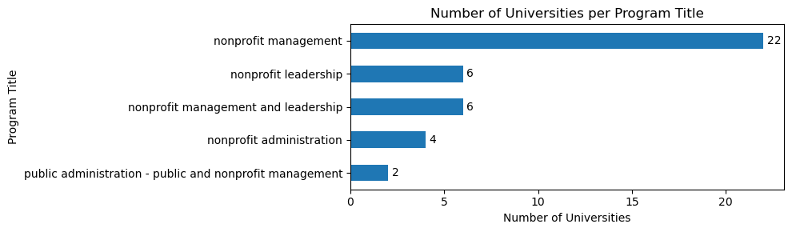

```python
# Module 5F: Grouped Program Title Analysis Bar Chart

df['program_title_clean'] = df['program_title'].str.lower().str.strip()

df['program_title_clean'] = df['program_title_clean'].replace({
    'nonprofit management and leadership': 'nonprofit management and leadership',
    'nonprofit leadership and management': 'nonprofit management and leadership',
    'nonprofit leadership (online)': 'nonprofit leadership'
})

# Count unique universities per program_title
program_counts = (
    df.groupby('program_title_clean')['university']
    .nunique()
    .sort_values(ascending=True)
)

program_counts = program_counts.tail(5)

plt.figure(figsize=(10, 3))

ax = program_counts.plot(kind='barh')

# Add value labels to the right of each bar
for i, v in enumerate(program_counts):
    ax.text(v + 0.2, i, str(v), va='center')

plt.title("Number of Universities per Program Title")
plt.xlabel("Number of Universities")
plt.ylabel("Program Title")

plt.tight_layout()
plt.show()
```

#### Module 5F1: Table of University Names by Program Type

```python
# Module 5F1: Table of University Names by Program Type

# Clean program titles
df['program_title_clean'] = df['program_title'].str.lower().str.strip()

df['program_title_clean'] = df['program_title_clean'].replace({
    'nonprofit management and leadership': 'Nonprofit Management and Leadership',
    'nonprofit leadership and management': 'Nonprofit Management and Leadership',
    'nonprofit leadership (online)': 'Nonprofit Leadership'
})

# Remove duplicate university–program combinations
df_unique = df.drop_duplicates(subset=['university', 'program_title_clean'])

# Recreate counts (same as plot)
program_counts = (
    df_unique.groupby('program_title_clean')['university']
    .nunique()
    .sort_values(ascending=True)
)

# Keep only top 5
program_counts = program_counts.tail(5)

# Filter dataset to only those program titles
df_multi = df_unique[df_unique['program_title_clean'].isin(program_counts.index)]

# Sort data
df_multi = df_multi.sort_values(['program_title_clean', 'university'])

# Group into lists
pivot_dict = (
    df_multi
    .groupby('program_title_clean')['university']
    .apply(list)
    .to_dict()
)

# Create pivot DataFrame
pivot_df = pd.DataFrame(dict([(k, pd.Series(v)) for k, v in pivot_dict.items()]))

# ORDER COLUMNS (descending like visual top → bottom)
ordered_cols = list(program_counts.index[::-1])  # reverse for descending
pivot_df = pivot_df[ordered_cols]

# Final formatting
pivot_df = pivot_df.fillna('').reset_index(drop=True)

# Styling: left-align everything
styled_table = (
    pivot_df.style
    .set_properties(**{'text-align': 'left'})
    .set_table_styles([
        {'selector': 'th', 'props': [('text-align', 'left')]}
    ])
)

display(styled_table)
```

|  | nonprofit management | Nonprofit Management and Leadership | nonprofit leadership | nonprofit administration | public administration - public and nonprofit management |
| --- | --- | --- | --- | --- | --- |
| 0 | American Public University System | Arizona State University Digital Immersion | Bradley University | John Carroll University | Liberty University |
| 1 | Antoich University | Metropolitan State University | Bushnell University | Louisiana State University-Shreveport | University of Central Oklahoma |
| 2 | Columbia University | University of Georgia | Central Michigan University | Maranatha Baptist University |  |
| 3 | Depaul University | University of Maryland Global Campus | La Salle University | University of Notre Dame |  |
| 4 | Florida Atlantic University | University of San Diego | Oklahoma City University |  |  |
| 5 | George Mason University | Walden University |  |  |  |
| 6 | George Washington University |  |  |  |  |
| 7 | Grace College and Theological Seminary |  |  |  |  |
| 8 | Indiana University-Northwest |  |  |  |  |
| 9 | Johns Hopkins University |  |  |  |  |
| 10 | Liberty University |  |  |  |  |
| 11 | North Park University |  |  |  |  |
| 12 | Northeastern University |  |  |  |  |
| 13 | Regis University |  |  |  |  |
| 14 | The University of Tennessee-Chattanooga |  |  |  |  |
| 15 | University of Central Florida |  |  |  |  |
| 16 | University of Memphis |  |  |  |  |
| 17 | University of Nevada-Las Vegas |  |  |  |  |
| 18 | University of Oregon |  |  |  |  |
| 19 | University of Portland |  |  |  |  |
| 20 | Washington University in St Louis |  |  |  |  |
| 21 | Worcester State University |  |  |  |  |

## Word Frequency Analysis - Unigram, Bigram and Trigrams

#### Module 5G: Unigram Word Frequency Analysis

This module counts how often each word appears across all course descriptions and then shows the 20 most frequently used words. The most frequently used words across course descriptions are “nonprofit” (484 occurrences), "course (408), “organizations” (306), "students" (252), and “management” (250), indicating a strong emphasis on nonprofit organizational management in the curriculum.

```python
# Module 5G: Unigram Word Frequency Analysis

# Word frequency analysis
# Shows the most common words across all course descriptions
from collections import Counter

# Rebuild tokens AFTER cleaning
all_tokens = [w for row in df['tokens'] for w in row]

# Word frequency
top_words = Counter(all_tokens).most_common(20)

print("Top 20 Words:\n", top_words)
```

```
Top 20 Words:
 [('nonprofit', 484), ('course', 408), ('organizations', 306), ('students', 252), ('management', 250), ('public', 194), ('financial', 167), ('social', 146), ('leadership', 130), ('development', 116), ('organization', 103), ('fundraising', 102), ('sector', 100), ('strategies', 99), ('research', 96), …
```

#### Module 5H: Unigram Word Frequency Analysis Bar Chart

In this module, I show a bar chart of the top 20 words used in the course descriptions.

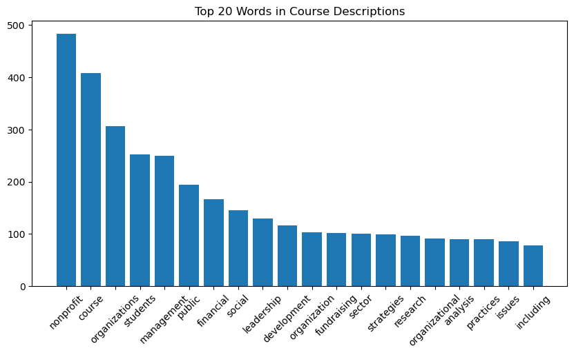

```python
# Module 5H: Unigram Word Frequency Analysis Bar Chart

import matplotlib.pyplot as plt

words, counts = zip(*top_words)

plt.figure(figsize=(10,5))
plt.bar(words, counts)
plt.xticks(rotation=45)
plt.title("Top 20 Words in Course Descriptions")
plt.show()
```

#### Module 5I: Bigram Analysis (2-word phrases)

This module shows a bigram analysis. I vet the corpora analyzing bigrams prior to trigrams (3-word combinations) because they are simpler and more general than trigrams. The bigrams help me identify basic, frequently used word pairs that may be generic or non-informative, which I characterize as "filler" phrases. The bigram analysis shows that the most common word pairs. For example, ['nonprofit', 'organizations', 'financial', 'management'] becomes [('nonprofit','organizations'), ('organizations','financial'), ('financial','management')], which may show a focus on managing nonprofit entities and financial management skills. Trigrams, on the other hand, are more context-dependent and may capture phrases that make sense only in a specific context. They require more tokens to form meaningful combinations, making them more complex to analyze and filter at the outset. Only after I conduct a bigram analysis will the trigram analysis be more focused, making it easier to identify more meaningful three-word phrases.

```python
# Module 5I: Bigram Analysis (2-word phrases)

# Bigrams (2-word combinations)
bigram_list = list(bigrams(all_tokens))
top_bigrams = Counter(bigram_list).most_common(20)
print("\nTop 20 Bigrams:\n", top_bigrams)
```

```
Top 20 Bigrams:
 [(('nonprofit', 'organizations'), 168), (('nonprofit', 'sector'), 43), (('course', 'provides'), 36), (('public', 'administration'), 35), (('financial', 'management'), 31), (('nonprofit', 'management'), 31), (('nonprofit', 'organization'), 30), (('public', 'nonprofit'), 29), (('students', 'learn'), …
```

#### Module 5J: Bigram Bar Chart

In this module, I present a bigram bar chart of the most common 2-word phrases used in nonprofit course descriptions.

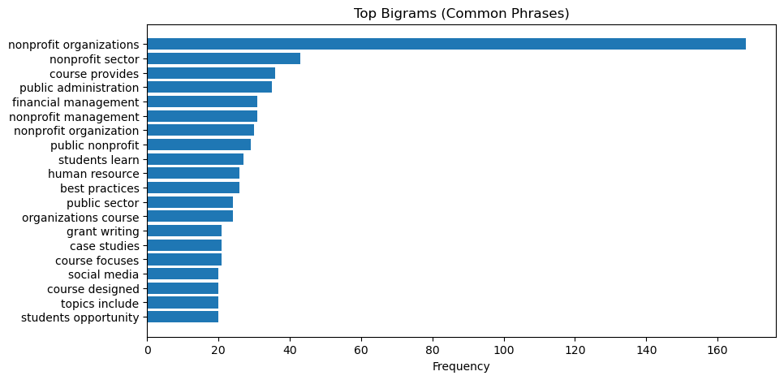

```python
# Module 5J: Bigram Bar Chart

# Sort the bigrams by frequency in descending order
top_bigrams_sorted = sorted(top_bigrams, key=lambda x: x[1], reverse=True)

# Create the bigram labels and counts for the bar chart
bigrams_labels = [' '.join(b) for b, _ in top_bigrams_sorted]
bigrams_counts = [count for _, count in top_bigrams_sorted]

# Plotting the bar chart
import matplotlib.pyplot as plt

plt.figure(figsize=(10,5))
plt.barh(bigrams_labels, bigrams_counts)
plt.title("Top Bigrams (Common Phrases)")
plt.xlabel('Frequency')
plt.gca().invert_yaxis()  # This line ensures the most frequent bigrams are at the top
plt.show()
```

#### Module 5K: Bigram Filler Phrase Detection and Removal

```python
# Module 5K: Bigram Filler Phrase Detection and Removal

filler_phrases = set([
    ('nonprofit', 'organizations')

])

# Function to remove filler phrases
def remove_filler(tokens):
    cleaned = []
    i = 0
    while i < len(tokens) - 1:  # Loop through the tokens
        # Check if the current token and the next token form a filler phrase
        if (tokens[i], tokens[i+1]) in filler_phrases:
            i += 2  # Skip the next token (i.e., remove the filler phrase)
        else:
            cleaned.append(tokens[i])  # Keep the current token
            i += 1  # Move to the next token
    # Add the last token if it wasn't part of a filler phrase
    if i < len(tokens):
        cleaned.append(tokens[i])
    return cleaned

# Apply the remove_filler function to the tokenized course descriptions
df['tokens_clean'] = df['tokens'].apply(remove_filler)

# Create the cleaned text after filler phrases are removed
df['clean_text'] = df['tokens_clean'].apply(lambda x: " ".join(x))
```

#### Module 5L: Rerun Bigram After Filler Phrase Removal

```python
# Module 5L: Rerun Bigram After Filler Phrase Removal

from nltk.util import ngrams
from collections import Counter

# Generate bigrams per row
df['bigrams_clean'] = df['tokens_clean'].apply(lambda x: list(ngrams(x, 2)))

# Flatten safely
bigram_list_clean = [bg for row in df['bigrams_clean'] for bg in row]

# Count frequencies
top_bigrams_clean = Counter(bigram_list_clean).most_common(20)

print("\nTop 20 Cleaned Bigrams:\n", top_bigrams_clean)
```

```
Top 20 Cleaned Bigrams:
 [(('nonprofit', 'sector'), 43), (('course', 'provides'), 36), (('public', 'administration'), 35), (('financial', 'management'), 31), (('nonprofit', 'management'), 31), (('nonprofit', 'organization'), 30), (('students', 'learn'), 27), (('human', 'resource'), 26), (('best', 'practices'), 26), (('publ…
```

#### Module 5M: Replot Bigram After Filler Phrase Removal

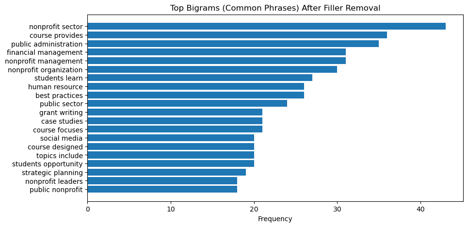

```python
# Module 5M: Replot Bigram After Filler Phrase Removal

import matplotlib.pyplot as plt

bigrams_labels_clean = [' '.join(b) for b, _ in top_bigrams_clean]
bigrams_counts_clean = [count for _, count in top_bigrams_clean]

plt.figure(figsize=(10, 5))
plt.barh(bigrams_labels_clean, bigrams_counts_clean)

plt.title("Top Bigrams (Common Phrases) After Filler Removal")
plt.xlabel('Frequency')

plt.gca().invert_yaxis()
plt.show()
```

#### Module 5N: Trigrams (3-word combinations)

```python
# Module 5N: Trigrams (3-word combinations)

from nltk.util import ngrams
from collections import Counter

# Generate trigrams per row
df['trigrams_clean'] = df['tokens_clean'].apply(lambda x: list(ngrams(x, 3)))

# Flatten safely
trigram_list = [tg for row in df['trigrams_clean'] for tg in row]

# Get top trigrams
top_trigrams = Counter(trigram_list).most_common(20)

print("\nTop 20 Trigrams (from cleaned tokens):\n", top_trigrams)
```

```
Top 20 Trigrams (from cleaned tokens):
 [(('human', 'resource', 'management'), 12), (('certificate', 'nonprofit', 'management'), 12), (('offers', 'students', 'opportunity'), 12), (('course', 'designed', 'provide'), 8), (('students', 'opportunity', 'learn'), 8), (('elective', 'course', 'certificate'), 8), (('course', 'certificate', 'nonpr…
```

#### Module 5O: Plot a Trigram Horizontal Bar Chart

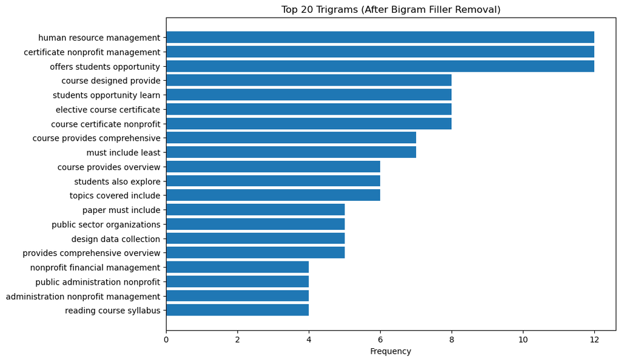

```python
# Module 5O: Plot Trigram Horizontal Bar Chart

import matplotlib.pyplot as plt

# Use top_trigrams from Module 5N directly
trigram_labels = [' '.join(trigram) for trigram, _ in top_trigrams]
trigram_counts = [count for _, count in top_trigrams]

plt.figure(figsize=(10, 7))
plt.barh(trigram_labels, trigram_counts)

plt.xlabel('Frequency')
plt.title('Top 20 Trigrams (After Bigram Filler Removal)')

plt.gca().invert_yaxis()
plt.show()
```

#### Module 5P: Trigram Filler Phrase Detection and Removal

```python
# Module 5P: Trigram Filler Phrase Detection and Removal

from nltk.util import ngrams
from collections import Counter

# Define filler trigrams
filler_trigrams = set([
    ('must', 'include', 'least'),
    ('paper', 'must', 'include'),
    ('students', 'complete', 'related'),
    ('related', 'checklist', 'found')
])

def remove_filler_trigrams(tokens):
    cleaned = []
    i = 0

    while i < len(tokens) - 2:
        if (tokens[i], tokens[i+1], tokens[i+2]) in filler_trigrams:
            i += 3
        else:
            cleaned.append(tokens[i])
            i += 1

    while i < len(tokens):
        cleaned.append(tokens[i])
        i += 1

    return cleaned

# Apply cleaning of filler phrases
df['tokens_clean_2'] = df['tokens_clean'].apply(remove_filler_trigrams)

# Generate trigrams from cleaned tokens
df['trigrams_clean'] = df['tokens_clean_2'].apply(lambda x: list(ngrams(x, 3)))

# Flatten
all_trigrams = [tg for row in df['trigrams_clean'] for tg in row]

# Count
top_trigrams = Counter(all_trigrams).most_common(50)

print(top_trigrams)
```

```
[(('human', 'resource', 'management'), 12), (('certificate', 'nonprofit', 'management'), 12), (('offers', 'students', 'opportunity'), 12), (('course', 'designed', 'provide'), 8), (('students', 'opportunity', 'learn'), 8), (('elective', 'course', 'certificate'), 8), (('course', 'certificate', 'nonpro…
```

#### Module 5Q: Replot Trigram After Filler Phrase Removal

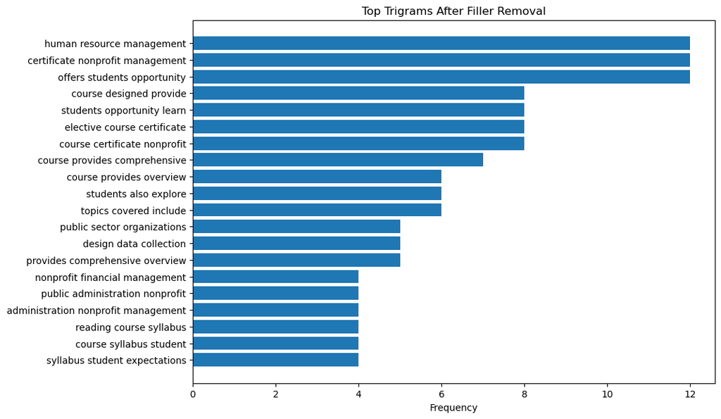

```python
# Module 5Q: Replot Trigram After Filler Phrase Removal

from nltk.util import trigrams
from collections import Counter
import matplotlib.pyplot as plt

# Generate trigrams per row
trigram_list_clean = [
    tg
    for row in df['tokens_clean_2']
    for tg in trigrams(row)
]

# Count
top_trigrams_clean = Counter(trigram_list_clean).most_common(20)

# Labels
trigram_labels_clean = [' '.join(t) for t, _ in top_trigrams_clean]
trigram_counts_clean = [count for _, count in top_trigrams_clean]

# Plot
plt.figure(figsize=(10,7))
plt.barh(trigram_labels_clean, trigram_counts_clean)
plt.title("Top Trigrams After Filler Removal")
plt.xlabel('Frequency')
plt.gca().invert_yaxis()
plt.show()
```

## Module 5R: POS (Part-of-Speech) Tagging and Co-occurrence Context Analysis

This module contextually examines how important words are actually used in sentences to see whether they are being discussed as ideas (like “nonprofit organization”) or as actions (like “topics covered include”). It shows patterns in language, not what the words actually mean. POS Tagging is focused on grammatical roles (noun, verb, etc.), and co-occurrence refers to which words appear near each other.

### Module 5R.1: POS Tagging and Co-occurrence Context Analysis (Corpora as a Whole)

Most of the language in these course descriptions focuses on ideas and concepts, not actions. Over 56% of all words are nouns, with common examples like “theory,” “scope,” “functions,” and “sector.” In contrast, only about 18.6% are verbs, and many of those are passive words like “covered” or “including.” This suggests the courses are described more like academic subjects rather than what students will actually do.

The descriptions also rely heavily on standard, template-like language, which shows up in pairs like “course provides” and “students learn.” Even though adjectives make up about 21.4% of the language, adding descriptive detail, much of the structure still follows repetitive patterns that make programs sound similar.

Overall, the surprising takeaway is that these programs emphasize what is taught more than how students will apply it. Even practical skills like “grant writing,” “human resource,” and “best practices” appear less frequently, suggesting that while hands-on learning exists, it is not the primary focus of how these courses are described.

```python
# Module 5R.1: POS Tagging and Co-occurrence Context Analysis (Answers “How do all the words in the corpora relate?”)

# Apply POS tagging to each tokenized row
from nltk import pos_tag
nltk.download('averaged_perceptron_tagger_eng', quiet=True)
from collections import defaultdict, Counter

df['pos_tags'] = df['tokens'].apply(pos_tag)

# Extract nouns and verbs separately (concept vs action)
def extract_pos(tags, pos_prefix):
    return [word for word, pos in tags if pos.startswith(pos_prefix)]

df['nouns'] = df['pos_tags'].apply(lambda x: extract_pos(x, 'NN'))
df['verbs'] = df['pos_tags'].apply(lambda x: extract_pos(x, 'VB'))

# Flatten all POS tags
all_pos = [pos for row in df['pos_tags'] for (_, pos) in row]

# Count frequencies
pos_counts = Counter(all_pos)

# Group into categories
pos_summary = {
    'Nouns': sum(count for tag, count in pos_counts.items() if tag.startswith('NN')),
    'Verbs': sum(count for tag, count in pos_counts.items() if tag.startswith('VB')),
    'Adjectives': sum(count for tag, count in pos_counts.items() if tag.startswith('JJ')),
    'Adverbs': sum(count for tag, count in pos_counts.items() if tag.startswith('RB')),
}

# Total tokens
total_tokens = sum(pos_counts.values())

# Print summary counts
print("\nPOS Category Summary:")
for category, count in pos_summary.items():
    print(f"{category}: {count}")

# Print percentages
print("\nPOS Distribution (%):")
for category, count in pos_summary.items():
    percent = (count / total_tokens) * 100
    print(f"{category}: {percent:.2f}%")


# Co-occurrence

window_size = 2
co_occurrence = defaultdict(int)

for tokens in df['tokens']:
    for i in range(len(tokens)):
        for j in range(i+1, min(i+window_size+1, len(tokens))):
            pair = tuple(sorted([tokens[i], tokens[j]]))
            co_occurrence[pair] += 1

# Display sample outputs
print("\nSample POS tags:", df['pos_tags'].iloc[0][:10])
print("Top noun examples:", df['nouns'].iloc[0][:10])
print("Top verb examples:", df['verbs'].iloc[0][:10])

# Top co-occurring pairs
top_pairs = sorted(co_occurrence.items(), key=lambda x: x[1], reverse=True)[:20]
print("\nTop co-occurring word pairs:", top_pairs)
```

```
POS Category Summary:
Nouns: 9785
Verbs: 3224
Adjectives: 3732
Adverbs: 347

POS Distribution (%):
Nouns: 56.28%
Verbs: 18.54%
Adjectives: 21.47%
Adverbs: 2.00%

Sample POS tags: [('theory', 'NN'), ('size', 'NN'), ('scope', 'NN'), ('functions', 'NNS'), ('nonprofit', 'VBP'), ('voluntary', 'JJ'), ('sector', 'NN'), ('covered', 'VBD'), ('multiple', 'JJ'), ('disciplinary', 'JJ')]
Top noun examples: ['theory', 'size', 'scope', 'functions', 'sector', 'perspectives']
Top verb examples: ['nonprofit', 'covered', 'including']

Top co-occurring word pairs: [(('nonprofit', 'organizations'), 184), (('management', 'nonprofit'), 63), (('nonprofit', 'public'), 53), (('nonprofit', 'sector'), 51), (('course', 'students'), 45), (('financial', 'management'), 44), (('administration', 'public'), 37), (('learn', 'students'), 37), (('c…
```

### Module 5R.2: POS Tagging and Co-occurrence Context Analysis (Using Specific Words)

This module examines a small set of key words found in the course descriptions: nonprofit, management, public, and business. The code shows how these keywords are used in context. The code identifies each occurrence of these words and extracts a small window of surrounding words (two before and two after). The resulting phrases are short token-based fragments that illustrate how each word is used, based on preprocessed text where stopwords have been removed, and meaningful bigrams and trigrams have been preserved.

The results indicate that the word "Nonprofit" appears primarily in the context of organizations and management. For example, “nonprofit sector” and “nonprofit management”. The phrases seem to focus more on real-world organizational structures and not abstract ideas.

The results indicate that the word "Management" appears primarily as a connector across various areas of management. For example, “human resource management” and “management staff”. The phrases seem to focus more on people, functions, and systems.

The results indicate that the word "Public" appears to be used primarily in the context of government and policy. For example, “public administration” and “public policy”. The phrases seem to focus more on a strong connection to the public sector.

The results indicate that the word "Business" appears to be used primarily as a descriptor. For example, “business management” and “business graduates”. The phrases seem to focus more on nonprofit programs relative to business education, not as the focus.

```python
# Module 5R.2: POS Tagging and Co-occurrence Context Analysis (Answers “How are the target words in the list below used?”)

nltk.download('averaged_perceptron_tagger', quiet=True)
nltk.download('averaged_perceptron_tagger_eng', quiet=True)  # If 'averaged_perceptron_tagger' doesn't resolve the issue
from nltk import pos_tag
from collections import defaultdict

# Target words
target_words = ['nonprofit', 'management', 'public', 'business']

df['pos_tags'] = df['tokens_clean_2'].apply(pos_tag)

# Context storage
context_dict = defaultdict(list)

window_size = 2

for tokens in df['tokens_clean_2']:
    for i, word in enumerate(tokens):
        if word in target_words:
            left = tokens[max(0, i - window_size):i]
            right = tokens[i + 1:i + 1 + window_size]
            context = left + [word] + right
            context_dict[word].append(" ".join(context))

# Display results
for word, contexts in context_dict.items():
    print(f"\n{word.upper()} (sample contexts):\n")
    for c in contexts[:5]:
        print("-", c)
```

```
NONPROFIT (sample contexts):

- scope functions nonprofit voluntary sector
- key concepts nonprofit financial management
- understanding lead nonprofit organization students
- stakeholders involved nonprofit management formerly
- programs sector nonprofit management relatively

MANAGEMENT (sample contexts):

- human resource management areas necessary
- motivation applicable management staff volunteers
- role society management issues public
- nonprofit financial management working knowledge
- involved nonprofit management formerly busi

PUBLIC (sample contexts):

- management issues public policy affecting
- business management public administration nonprofit
- presented church public agency employer
- introduction discipline public administration class
- profession study public administration major

BUSINESS (sample contexts):

- focus coursework business graduate programs
- field compared business management public
- recognizes many business graduates may
- although business make money
- starting acquiring business students examine
```

## Module 6: Unigram TF–IDF + Cosine Similarity

#### Module 6A: Unigram TF–IDF Distinctiveness

This module analyzed 616 course descriptions across 1,482 terms. It shows that the language in the course descriptions is concentrated around a relatively small set of core ideas. The most distinctive terms are "nonprofit," "public," "management," "financial," and "leadership". They indicate that programs are primarily focused on managing nonprofit organizations within a broader public and social context. The prominence of words like "course," "students," "covers," and "examines" indicates that a significant portion of the language is generic and instructional rather than highly specialized. There are non-generic terms such as "strategies," "planning," "fundraising," and "development", which indicate references to applied skills in the course descriptions. The overall pattern reflects a strong emphasis on conceptual structure and standardized phrasing.

The low TF-IDF scores indicate that course descriptions are largely consistent across programs, with limited differentiation in how content is presented. The reported low standard deviation scores of 0.10 or less indicate that words appear uneven across course descriptions.

```python
# Module 6A: Unigram TF–IDF Distinctiveness

from sklearn.feature_extraction.text import TfidfVectorizer
import pandas as pd

# Build corpus
docs = df['tokens_clean_2'].apply(lambda x: " ".join(x))

# TF–IDF
vectorizer = TfidfVectorizer(
    lowercase=False,
    tokenizer=lambda x: x.split(),
    preprocessor=None,
    token_pattern=None,
    min_df=2
)

tfidf_matrix = vectorizer.fit_transform(docs)

tfidf_df = pd.DataFrame(
    tfidf_matrix.toarray(),
    columns=vectorizer.get_feature_names_out()
)

print("TF-IDF matrix shape:", tfidf_df.shape)

# Mean and Standard Deviation
summary_uni = pd.DataFrame({
    'mean': tfidf_df.mean(axis=0),
    'std': tfidf_df.std(axis=0)
})

# Top 20 terms by mean
top_terms = summary_uni.sort_values(by='mean', ascending=False).head(20)

print("\nTop Unigram Terms (Mean + Std):\n")
print(top_terms.round(3))
```

```
TF-IDF matrix shape: (616, 1482)

Top Unigram Terms (Mean + Std):

                mean    std
nonprofit      0.052  0.080
public         0.043  0.091
management     0.042  0.078
course         0.040  0.058
financial      0.036  0.101
students       0.031  0.058
leadership     0.031  0.081
strategies     0.026  0.073
organizations  0.026  0.068
social         0.026  0.077
fundraising    0.025  0.088
practices      0.025  0.075
covers         0.025  0.082
sector         0.025  0.070
development    0.024  0.065
focuses        0.024  0.077
examines       0.023  0.069
research       0.022  0.077
principles     0.022  0.075
planning       0.022  0.078
```

#### Module 6B: Unigram Cosine Similarity

This module shows the unigram cosine similarity results and how similar each course description is to the others. The 616 × 616 matrix means every course is compared with all others. The average similarity of 0.039 is very low, indicating that most descriptions differ significantly in their exact wording. For example, one course might say “financial management and strategic planning in nonprofit organizations,” while another says “resource development and budgeting for social sector agencies.” These describe similar ideas but use different language, resulting in low similarity scores.

The maximum similarity score of 1.0 likely reflects duplicate course descriptions across programs within the same institution, as discussed earlier. This reuse of course descriptions results in perfect similarity scores, indicating that the overlap is structural (shared courses) rather than conceptual similarity across different institutions.

```python
# Module 6B: Unigram Cosine Similarity

from sklearn.metrics.pairwise import cosine_similarity

tfidf_matrix = vectorizer.fit_transform(docs)
cosine_matrix = cosine_similarity(tfidf_matrix)

cosine_df = pd.DataFrame(
    cosine_matrix,
    index=df.index,
    columns=df.index
)

print("\nCosine similarity matrix shape:", cosine_df.shape)

# Summary Metrics

np.fill_diagonal(cosine_matrix, np.nan)

print("\nAverage similarity:", round(np.nanmean(cosine_matrix), 3))
print("Max similarity:", round(np.nanmax(cosine_matrix), 3))
print("Min similarity:", round(np.nanmin(cosine_matrix), 3))
```

```
Cosine similarity matrix shape: (616, 616)

Average similarity: 0.039
Max similarity: 1.0
Min similarity: 0.0
```

#### Module 6C: Convert Similarity Matrix to Network Graph for Later SNA Analysis

**Module 6C** converts the cosine similarity matrix into a network structure. Then it can later be analyzed using social network analysis methods. Each institution becomes a node, and the similarity scores between them become weighted connections (edges), allowing the relationships to be studied as a system rather than as isolated pairwise comparisons. This enables the analysis to move beyond simple similarity scores and into structural insights such as influence and connectivity. It shows a unigram similarity network with 616 nodes and 117,515 edges (connections), in which institutions share some level of word-level similarity. This network is dense, meaning most institutions are connected to many others based on shared vocabulary in their course descriptions. Compared to a fully connected network (which would have (616 × 615) / 2 = 189,420 edges), this indicates that unigram similarity captures a very broad level of overlap. This means many institutions appear similar when viewed solely at the level of individual words, because common terms are widely used across course descriptions.

Unigram analysis tends to emphasize general, shared language rather than distinct phrasing. As a result, the network includes a large number of connections, many of which are relatively weak or generic. From an SNA perspective, this makes it difficult to immediately identify meaningful structure, such as clear clusters because everything is so interconnected. The network analysis will later need to apply a threshold to remove weaker connections. As weaker ties are filtered out, the network should begin to separate into smaller, more meaningful groups, helping to reveal which institutions are truly similar in their use of language and which are only loosely connected through common, generic terms.

```python
# Module 6C: Convert Similarity Matrix to Network Graph for Later SNA Analysis

import networkx as nx

G_uni = nx.from_pandas_adjacency(cosine_df)
G_uni.remove_edges_from(nx.selfloop_edges(G_uni))

print("Unigram network:")
print("Nodes:", G_uni.number_of_nodes())
print("Edges:", G_uni.number_of_edges())
```

```
Unigram network:
Nodes: 616
Edges: 117515
```

## Module 7: Bigram TF-IDF + Cosine Matrix

#### Module 7A: BigramTF–IDF Distinctiveness

**Module 7A** identifies the most distinctive two-word phrases (bigrams) across the entire corpus. Bigrams may reveal concept-level language rather than isolated words. Each score represents the mean TF–IDF weight of that phrase across all documents. Higher values indicate phrases that are both frequent within documents and discriminative across the corpus. The results show a strong concentration around three thematic clusters. First, the phrases “nonprofit sector,” “public administration,” “public sector,” and “nonprofit management” suggest that the dataset is more focused on nonprofit and government-oriented programs. Second, there is a management and organizational theme surfacing, reflected in phrases such as “financial management,” “strategic planning,” and “human resource.” These suggest that programs emphasize business. Third, there is a mix of instructional and academic language, including “course provides,” “students learn,” “capstone course,” and “research methods.” These are more filler phrases, discussed earlier. They reflect common academic framing rather than domain-specific differentiation.

The reported low standard deviation scores of 0.08 or less indicate that phrases appear uneven across course descriptions.

```python
# Module 7A: BigramTF–IDF Distinctiveness

from sklearn.feature_extraction.text import TfidfVectorizer
import pandas as pd

# Build corpus
docs = df['tokens_clean_2'].apply(lambda x: " ".join(x))

# TF–IDF Vectorizer
vectorizer_bg = TfidfVectorizer(
    lowercase=False,
    tokenizer=lambda x: x.split(),
    preprocessor=None,
    token_pattern=None,
    min_df=2,
    ngram_range=(2, 2)
)

tfidf_matrix_bg = vectorizer_bg.fit_transform(docs)
tfidf_df_bg = pd.DataFrame(
    tfidf_matrix_bg.toarray(),
    columns=vectorizer_bg.get_feature_names_out()
)

print("Bigram TF-IDF matrix shape:", tfidf_df_bg.shape)

# Mean and Standard Deviation
summary_bg = pd.DataFrame({
    'mean': tfidf_df_bg.mean(axis=0),
    'std': tfidf_df_bg.std(axis=0)
})

# Top 20 by mean
top_bigrams = summary_bg.sort_values(by='mean', ascending=False).head(20)

print("\nTop Distinctive Bigrams (Mean and Standard Deviation):\n")
print(top_bigrams.round(3))
```

```
Bigram TF-IDF matrix shape: (616, 2439)

Top Distinctive Bigrams (Mean and Standard Deviation):

                         mean    std
nonprofit sector        0.017  0.080
public administration   0.015  0.074
best practices          0.012  0.073
public sector           0.012  0.068
nonprofit management    0.011  0.074
financial management    0.011  0.052
course provides         0.010  0.046
nonprofit organization  0.010  0.055
human resource          0.010  0.054
strategic planning      0.009  0.061
public policy           0.009  0.059
research methods        0.008  0.060
social change           0.008  0.068
principles practices    0.008  0.056
public nonprofit        0.008  0.054
students learn          0.008  0.042
students opportunity    0.008  0.046
capstone course         0.008  0.054
case studies            0.008  0.045
social media            0.008  0.070
```

#### Module 7B: Bigram Cosine Similarity

**Module 7B** examines bigram cosine similarity analysis to see if shared themes translate into similarity at the phrase level across individual course descriptions. The results suggest that they are not similar. Despite the presence of common thematic clusters, the average cosine similarity of 0.006 indicates that course descriptions rarely use the same two-word combinations. In other words, while programs may consistently discuss similar topics such as nonprofit management or public sector work, they tend to express these ideas using different phrasing, resulting in minimal overlap in bigrams. These results indicate that the dataset is conceptually cohesive but linguistically heterogeneous. Course descriptons align in subject matter but diverge in how they articulate those concepts.

```python
# Module 7B: Bigram Cosine Similarity

from sklearn.metrics.pairwise import cosine_similarity
import pandas as pd
import numpy as np

# Cosine similarity using Bigram TF-IDF matrix
cosine_matrix_bg = cosine_similarity(tfidf_matrix_bg)

cosine_df_bg = pd.DataFrame(
    cosine_matrix_bg,
    index=df.index,
    columns=df.index
)

print("\nBigram Cosine similarity matrix shape:", cosine_df_bg.shape)

# Summary metrics
np.fill_diagonal(cosine_matrix_bg, np.nan)

print("\nAverage similarity:", round(np.nanmean(cosine_matrix_bg), 3))
print("Max similarity:", round(np.nanmax(cosine_matrix_bg), 3))
print("Min similarity:", round(np.nanmin(cosine_matrix_bg), 3))
```

```
Bigram Cosine similarity matrix shape: (616, 616)

Average similarity: 0.006
Max similarity: 1.0
Min similarity: 0.0
```

#### Module 7C: Convert Bigram Similarity Matrix to Network Graph for Later SNA Analysis

**Module 7C** shows a bigram similarity network that contains 616 nodes and 10,481 edges (connections) where institutions share some level of phrase-level similarity. The network is not nearly as dense as the unigram network, meaning many institutions share much less overlapping bigram language in their course descriptions. Bigrams are more selective than unigrams. This suggests that while institutions may differ in specific phrasing, there is still an underlying similarity in how course descriptions are constructed, with recurring phrases appearing across many schools. The fact that the network is not fully dense implies that bigrams are capturing more specific and distinguishing language patterns, which should lead to clearer clustering once weaker edges are filtered out. Like the Unigram Network discussion in Module 6C, applying a threshold will eliminate weak ties.

```python
# Module 7C: Convert Bigram Similarity Matrix to Network Graph for Later SNA Analysis

import networkx as nx

G_bi = nx.from_pandas_adjacency(cosine_df_bg)

# Remove self-loops
G_bi.remove_edges_from(nx.selfloop_edges(G_bi))

print("Bigram similarity network created:")
print("Nodes:", G_bi.number_of_nodes())
print("Edges:", G_bi.number_of_edges())
```

```
Bigram similarity network created:
Nodes: 616
Edges: 10481
```

## Module 8: Linguistic Signal Analysis by School Type

This module introduces a structured comparison of course descriptions across school types, building on prior evidence that program titles explain very little of the variation in language, while heterogeneity largely occurs within categories. The school types are divided by Public Administration (PA), Business (B), Social Sciences (S), Professional Studies (PS), and Other (O).

By segmenting the dataset by school_type, this module explores whether institutional context produces more meaningful linguistic distinctions than program titles. I examined between-group differences to gain further insight. Modules 8A1-3 identification, visualizes, and lists Universities by School Types. Modules 8B1-6 explore Unigram between-group insights. Modules 8C1-6 explores bigram between-group insights.

#### Module 8A1: Identification and Distribution of School Types

Public Administration (PA) represents the largest group with 248 observations, followed by Business (B) with 191. Smaller groups include S and PS, each with 67 observations, while O is the least represented, with 43 observations. Overall, the distribution is uneven, with PA and B comprising the majority of the dataset, while the remaining groups make up a smaller proportion.

```python
# Module 8A1: Identification and Distribution of School Types

print(df['school_type'].unique())
print(df['school_type'].value_counts())
```

```
['PA' 'B' 'S' 'PS' 'O']
school_type
PA    248
B     191
S      67
PS     67
O      43
Name: count, dtype: int64
```

#### Module 8A2: Visualization of the Distribution of School Types

In this module, I created a bar chart to visualize the distribution of School Types.

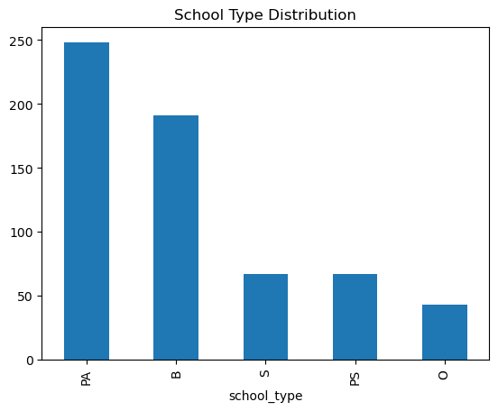

```python
# Module 8A2: Visualization of the Distribution of School Types

df['school_type'].value_counts().plot(kind='bar')
plt.title("School Type Distribution")
plt.show()
```

#### Module 8A3: Table of University Names by School Type

```python
# Module 8A3: Table of University Names by School Type

import pandas as pd
from IPython.display import display, HTML

# Use relevant columns
df_mod = df[COLS].copy()

# Remove missing values
df_mod = df_mod.dropna(subset=['university', 'school_type'])

# Keep unique university-school_type pairs
df_unique = df_mod[['university', 'school_type']].drop_duplicates()

# Sort values
df_unique = df_unique.sort_values(['school_type', 'university'])

# Build pivot
pivot_df = (
    df_unique
    .groupby('school_type')['university']
    .apply(list)
    .to_dict()
)

pivot_df = pd.DataFrame(dict([(k, pd.Series(v)) for k, v in pivot_df.items()]))

# Column order
desired_order = ['PA', 'B', 'S', 'PS', 'O']
existing_cols = [col for col in desired_order if col in pivot_df.columns]
pivot_df = pivot_df[existing_cols]

# Replace NaN with blanks
pivot_df = pivot_df.fillna('')

# Reset index
pivot_df = pivot_df.reset_index(drop=True)

# Styling
styled_table = (
    pivot_df.style
    .set_properties(**{'text-align': 'left'})
    .set_table_styles([
        {'selector': 'th', 'props': [('text-align', 'center')]}
    ])
)

# Title
display(HTML("<h3 style='text-align: center;'>Table of University Names by School Type</h3>"))
display(styled_table)
```

Table of University Names by School Type

|  | PA | B | S | PS | O |
| --- | --- | --- | --- | --- | --- |
| 0 | American Public University System | Antoich University | Bay Path University | Columbia University | Bay Path University |
| 1 | Arizona State University Digital Immersion | Bushnell University | Case Western Reserve University | Drexel University | Bradley University |
| 2 | Brandeis University | Cairn University-Langhorne | Grand Canyon University | Northeastern University | Drury University |
| 3 | CUNY Baruch College | Grace College and Theological Seminary | La Salle University | University of Denver | University of Lynchburg |
| 4 | California State University-Northridge | John Carroll University | Oklahoma City University | University of Georgia | University of San Diego |
| 5 | Central Michigan University | Liberty University | University of Chicago | University of Richmond |  |
| 6 | Cleveland State University | Lindenwood University | Washington University in St Louis |  |  |
| 7 | Depaul University | Louisiana State University-Shreveport |  |  |  |
| 8 | Florida Atlantic University | Maranatha Baptist University |  |  |  |
| 9 | George Mason University | Metropolitan State University |  |  |  |
| 10 | George Washington University | North Park University |  |  |  |
| 11 | Grand Valley State University | Regis University |  |  |  |
| 12 | Indiana University-Northwest | Shorter University |  |  |  |
| 13 | Johns Hopkins University | The University of Tennessee-Chattanooga |  |  |  |
| 14 | Kent State University at Kent | University of Central Oklahoma |  |  |  |
| 15 | Liberty University | University of Notre Dame |  |  |  |
| 16 | Metropolitan State University | University of Portland |  |  |  |
| 17 | New York University |  |  |  |  |
| 18 | Regent University |  |  |  |  |
| 19 | SUNY Buffalo State University |  |  |  |  |
| 20 | University of Baltimore |  |  |  |  |
| 21 | University of Central Florida |  |  |  |  |
| 22 | University of Maryland Global Campus |  |  |  |  |
| 23 | University of Memphis |  |  |  |  |
| 24 | University of Nevada-Las Vegas |  |  |  |  |
| 25 | University of Oregon |  |  |  |  |
| 26 | Walden University |  |  |  |  |
| 27 | Worcester State University |  |  |  |  |

#### Modules 8B1-6: Unigram TF–IDF Distinctiveness + Cosine Similarity Between School Types

Modules 8B1, 8B2, and 8B3 explore the prevalence of unigrams in course descriptions by School Type, using TF-IDF scores.

**Module 8B1** identifies the most distinctive vocabulary used by each school type. For each group (e.g., PA, B, S, PS, O), I filtered the dataset, computed the mean TF–IDF score for each term in that group, and selected the top 10 highest-scoring terms. These terms are the most emphasized in that group’s program descriptions. Each row shows the terms ordered by importance (from most to least). The output highlights both shared and unique language patterns across groups. For example, terms like “nonprofit,” “management,” and “course” appear across multiple columns. Because the ranking is done independently within each group, the table emphasizes relative importance rather than absolute differences, meaning a term’s position reflects its prominence within that group, not its numerical ranking across groups.

**Module 8B2** examines the importance of each word in course descriptions, broken down by each group. To do this, the code constructs a group-level mean TF–IDF comparison table to show how different school types use key terms. The table displays these globally important terms along with their TF–IDF scores for each group. Key points about the output: the terms listed (e.g., nonprofit, course, management) are the most globally salient across the entire dataset.

In **Module 8B3**, I examined shared words between each group. The table summarizes the shared top TF–IDF terms between pairs of groups. Each row represents a pair of groups (group_1 and group_2) and lists the terms that appear in the top-ranked vocabulary for both groups, based on earlier TF–IDF analysis. The output highlights overlapping language across groups, revealing where program descriptions converge conceptually. For example, terms like “nonprofit,” “management,” and “course” appear repeatedly across many group pairs, indicating a shared core vocabulary that is not strongly differentiating. The table is useful for identifying common thematic ground between groups, but it does not show how frequently each term is used; it only indicates whether it appears among the top terms for both groups.

In **Module 8B5**, I plotted a Unigram Boxplot - Between Groups. Most course descriptions share very little exact wording, regardless of group. The boxes almost completely overlap. The interquartile ranges are very similar, and the medians are close together.

**Module 8B6** extends the between-group analysis by translating group-level similarities into a network structure, allowing the relationships between school types to be examined more holistically. Rather than focusing on individual course descriptions, I treat each school type as a single node and represent the average similarity between groups as connections between them. The network analysis provides a structural view of group similarity, making it easier to assess whether certain school types cluster together or stand apart. This is particularly useful given earlier findings that similarities across groups are uniformly low, suggesting weak differentiation. The network representation allows confirmation whether a lack of differentiation persists when viewed as a system of relationships, rather than as pairwise comparisons alone.

```python
# Module 8B1: TF–IDF Unigram Distinctiveness Between School Types

# Build group_terms dictionary (top 10 per group)
group_terms = {}

for group in df['school_type'].unique():
    idx = df['school_type'] == group
    group_mean = tfidf_df.loc[idx].mean(axis=0)
    top_terms = group_mean.sort_values(ascending=False).head(10)
    group_terms[group] = top_terms

# Now create ranked table (no NaNs)
group_terms_ranked = pd.DataFrame({
    group: terms.index.tolist()
    for group, terms in group_terms.items()
})

print("\nTop 10 Terms by Group (Ranked):")
print(group_terms_ranked)
```

```
Top 10 Terms by Group (Ranked):
            PA            B               S              PS           O
0       public    nonprofit          course       nonprofit    students
1    nonprofit       course       nonprofit      management  leadership
2   management   management   organizations          social      course
3    financial    financial      leadership       practices      change
4       course   strategies        students         project       board
5       sector       public         leaders        examines    research
6  development  fundraising          social      leadership   nonprofit
7       covers     students  organizational  sustainability   financial
8    practices       covers     development          offers      social
9   principles     examines           learn          impact  management
```

```python
# Module 8B2: Full TF-IDF Unigram Comparison Table Between School Types

import pandas as pd

# Ensure index alignment
tfidf_df.index = df.index

group_mean_full = {
    g: tfidf_df[df['school_type'] == g].mean(axis=0)
    for g in df['school_type'].unique()
}

group_mean_df = pd.DataFrame(group_mean_full).fillna(0)

top_terms = group_mean_df.mean(axis=1).sort_values(ascending=False).head(10).index
group_mean_top_df = group_mean_df.loc[top_terms].round(3)

print("\nTop 10 Terms Across All Groups - The Highest Mean TF–IDF Across All Documents")
print(group_mean_top_df.to_string())
```

```
Top 10 Terms Across All Groups - The Highest Mean TF–IDF Across All Documents
                  PA      B      S     PS      O
nonprofit      0.052  0.049  0.052  0.064  0.046
course         0.036  0.045  0.052  0.022  0.056
management     0.051  0.037  0.024  0.040  0.038
leadership     0.027  0.025  0.042  0.030  0.058
students       0.028  0.028  0.040  0.025  0.061
financial      0.042  0.035  0.022  0.027  0.043
social         0.023  0.019  0.031  0.039  0.042
public         0.072  0.034  0.022  0.010  0.010
organizations  0.026  0.027  0.044  0.009  0.026
strategies     0.025  0.034  0.020  0.015  0.031
```

```python
# Module 8B3: Shared Top Unigram Terms Between School Types

import itertools
import pandas as pd
from sklearn.feature_extraction.text import TfidfVectorizer

# Validate required columns
if 'tokens' not in df.columns:
    raise ValueError("'tokens' column not found. Run preprocessing first.")

if 'school_type' not in df.columns:
    raise ValueError("'school_type' column not found.")

# Convert tokens to text
text_series = df['tokens'].apply(lambda x: ' '.join(x))

# Unigram TF-IDF
vectorizer = TfidfVectorizer(ngram_range=(1,1))
X = vectorizer.fit_transform(text_series)

feature_names = vectorizer.get_feature_names_out()

# Build TF-IDF DataFrame
df_tfidf = pd.DataFrame(X.toarray(), columns=feature_names)
df_tfidf['school_type'] = df['school_type'].values

# Compute group means
group_means = df_tfidf.groupby('school_type').mean()

# Extract top terms per group
top_n = 10
top_terms_per_group = {}

for group in group_means.index:
    top_terms = (
        group_means.loc[group]
        .sort_values(ascending=False)
        .head(top_n)
        .index
    )
    top_terms_per_group[group] = set(top_terms)

# Pairwise shared terms
rows = []

for g1, g2 in itertools.combinations(group_means.index, 2):
    shared_terms = top_terms_per_group[g1].intersection(top_terms_per_group[g2])

    rows.append({
        'group_1': g1,
        'group_2': g2,
        'shared_term': ', '.join(sorted(shared_terms))
    })

shared_terms_df = pd.DataFrame(rows).reset_index(drop=True)

# Styling
pd.set_option('display.max_colwidth', None)

display(
    shared_terms_df.style
    .set_properties(subset=['shared_term'], **{'text-align': 'left'})
    .set_table_styles([
        {'selector': 'th', 'props': [('text-align', 'left')]}
    ])
)
```

|  | group_1 | group_2 | shared_term |
| --- | --- | --- | --- |
| 0 | B | O | course, financial, nonprofit, organizations, students |
| 1 | B | PA | course, covers, financial, management, nonprofit, organizations, public |
| 2 | B | PS | management, nonprofit, organizations |
| 3 | B | S | course, nonprofit, organizations, students |
| 4 | O | PA | course, financial, nonprofit, organizations |
| 5 | O | PS | leadership, nonprofit, organizations, social |
| 6 | O | S | course, leadership, nonprofit, organizations, social, students |
| 7 | PA | PS | management, nonprofit, organizations, practices |
| 8 | PA | S | course, development, nonprofit, organizations |
| 9 | PS | S | leadership, nonprofit, organizations, social |

```python
# Module 8B4: Unigram Cosine Similarity Between School Types

import numpy as np
import pandas as pd

groups = df['school_type'].unique()
group_sim = pd.DataFrame(index=groups, columns=groups)

for g1 in groups:
    for g2 in groups:
        idx1 = df['school_type'] == g1
        idx2 = df['school_type'] == g2

        submat = cosine_matrix[np.ix_(idx1, idx2)]

        # remove self-comparisons for within-group
        if g1 == g2:
            np.fill_diagonal(submat, np.nan)

        group_sim.loc[g1, g2] = np.nanmean(submat)

group_sim = group_sim.astype(float)
group_sim_uni = group_sim.copy()

print("\nPairwise Cosine Similarity Between Groups:")
print(group_sim.round(3))
```

```
Pairwise Cosine Similarity Between Groups:
       PA      B      S     PS      O
PA  0.043  0.040  0.037  0.033  0.041
B   0.040  0.039  0.037  0.034  0.040
S   0.037  0.037  0.039  0.034  0.041
PS  0.033  0.034  0.034  0.037  0.037
O   0.041  0.040  0.041  0.037  0.053
```

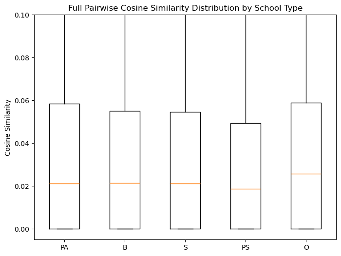

```python
# Module 8B5: Unigram Boxplot - Between Groups

import numpy as np
import matplotlib.pyplot as plt

groups = ['PA', 'B', 'S', 'PS', 'O']

data = []
labels = []

for g in groups:
    idx = df['school_type'] == g

    # all similarities involving this group (rows vs ALL columns)
    submat = cosine_matrix[idx, :].copy()

    # remove self-comparisons
    row_indices = np.where(idx)[0]
    for i, row in enumerate(row_indices):
        submat[i, row] = np.nan

    vals = submat.flatten()
    vals = vals[~np.isnan(vals)]

    data.append(vals)
    labels.append(g)

# Plot
plt.figure(figsize=(8,6))
plt.boxplot(data, tick_labels=labels)

plt.ylabel("Cosine Similarity")
plt.title("Full Pairwise Cosine Similarity Distribution by School Type")

# Add padding so boxes aren't cut off
plt.ylim(-0.005, 0.1)

plt.show()
```

```python
# Module 8B6: Unigram Between School Types SNA Network

import networkx as nx

# Compute average similarity between groups
group_sim = cosine_df.groupby(df['school_type']).mean()
group_sim = group_sim.T.groupby(df['school_type']).mean()

# Build network
G_groups = nx.from_pandas_adjacency(group_sim)

# Remove self-loops
G_groups.remove_edges_from(nx.selfloop_edges(G_groups))

print("Group-level network:")
print("Nodes:", G_groups.number_of_nodes())
print("Edges:", G_groups.number_of_edges())
```

```
Group-level network:
Nodes: 5
Edges: 10
```

#### Modules 8C1-6: Bigram TF-IDF + Cosine Matrix Similarities Between School Types

**Module 8C1** identifies the most distinctive bigram phrases used by each school type. For each group, I computed the mean TF–IDF score for each bigram within that group, and selected the top 10 highest-scoring phrases. These bigrams represent the most emphasized two-word concepts in each group’s program descriptions, capturing more specific meanings than single words. Each row shows the phrases ordered by importance from most to least, within each group. For example, phrases like “nonprofit organizations,” “public administration,” and “financial management” appear across multiple columns, indicating common thematic overlap, while other phrases (e.g., “students learn,” “capstone course,” or “strategic planning”) reflect more specialized emphases within particular school types.

In **Module 8C4**, I examined cosine similarities between school types using bigram-based TF–IDF representations. Results indicate that course descriptions are extremely diverse in their phrase-level language across all groups. Similarity values are uniformly very low, ranging from approximately 0.002 to 0.007, which is even lower than the unigram-based results. This suggests that while programs may share individual words, they rarely use the same two-word phrases in similar ways. For example, Public Administration (0.004) is only marginally more similar to Business (0.003) or Other programs (0.003), and these differences are negligible. Similarly, all cross-group comparisons cluster tightly within a very narrow range, indicating minimal distinction in similarity across different pairs of school types. Overall, the findings suggest that while programs share a general thematic vocabulary, the specific phrasing and structure of that language differ considerably across descriptions. Bigrams shows that shared conceptual phrases are far less common than shared individual words. As a result, linguistic similarity between school types is weak.

**Module 8C6** extends the between-group analysis by converting bigram-based group similarities into a network structure. Each school type is treated as a node, with connections representing average phrase-level similarity between groups.

```python
# Module 8C1: Bigram TF-IDF Distinctiveness Between School Types

from sklearn.feature_extraction.text import TfidfVectorizer
import pandas as pd

# Ensure required columns exist
if 'tokens' not in df.columns:
    raise ValueError("'tokens' column not found. Run preprocessing first.")

if 'school_type' not in df.columns:
    raise ValueError("'school_type' column not found.")

# Convert tokens to text
text_series = df['tokens'].apply(lambda x: ' '.join(x))

# Bigram TF-IDF
vectorizer = TfidfVectorizer(ngram_range=(2,2))
X = vectorizer.fit_transform(text_series)

feature_names = vectorizer.get_feature_names_out()

# TF-IDF dataframe
df_tfidf = pd.DataFrame(X.toarray(), columns=feature_names)

# Add grouping variable
df_tfidf['school_type'] = df['school_type'].values

# Compute group means
group_means = df_tfidf.groupby('school_type').mean()

# Build ranked table (like I reported in Module 7A1)
top_n = 10
ranked_dict = {}

for group in group_means.index:
    top_terms = (
        group_means.loc[group]
        .sort_values(ascending=False)
        .head(top_n)
        .index
    )
    ranked_dict[group] = list(top_terms)

# Convert to DataFrame (rows = rank, columns = group)
ranked_table = pd.DataFrame(ranked_dict)

print("Top 10 Bigrams by School Type (Ranked):\n")
ranked_table
```

```
Top 10 Bigrams by School Type (Ranked):
```

|  | B | O | PA | PS | S |
| --- | --- | --- | --- | --- | --- |
| 0 | nonprofit organizations | students learn | nonprofit organizations | nonprofit organizations | nonprofit organizations |
| 1 | nonprofit administration | nonprofit organizations | public administration | offers students | nonprofit leaders |
| 2 | nonprofit sector | financial management | public sector | students opportunity | social sector |
| 3 | fundraising strategies | course intended | public nonprofit | best practices | sector organizations |
| 4 | course provides | nonprofit civic | financial management | social media | course provides |
| 5 | public administration | civic organizations | resource development | focuses strategic | budgeting financial |
| 6 | topics include | social change | nonprofit sector | nonprofit organization | best practices |
| 7 | human resource | course focuses | public service | strategic planning | leadership nonprofit |
| 8 | public sector | prepare students | public policy | opportunity learn | focuses strategies |
| 9 | public nonprofit | communities nonprofit | nonprofit management | capstone course | planned giving |

```python
# Module 8C2: Bigram TF-IDF Comparison Table Between Groups

# Number of global bigrams to compare
top_n = 10

# Get globally important bigrams (based on overall mean TF-IDF)
top_global_bigrams = (
    group_means
    .mean(axis=0)
    .sort_values(ascending=False)
    .head(top_n)
    .index
)

# Build comparison table (rows = bigrams, columns = groups)
comparison_table = group_means[top_global_bigrams].T

# Optional: round for readability
comparison_table = comparison_table.round(4)

print("Bigram TF-IDF Comparison Across School Types:\n")
comparison_table
```

```
Bigram TF-IDF Comparison Across School Types:
```

| school_type | B | O | PA | PS | S |
| --- | --- | --- | --- | --- | --- |
| nonprofit organizations | 0.0206 | 0.0243 | 0.0254 | 0.0270 | 0.0233 |
| students learn | 0.0038 | 0.0293 | 0.0010 | 0.0000 | 0.0069 |
| best practices | 0.0044 | 0.0047 | 0.0029 | 0.0164 | 0.0109 |
| financial management | 0.0047 | 0.0190 | 0.0104 | 0.0028 | 0.0014 |
| nonprofit sector | 0.0084 | 0.0040 | 0.0099 | 0.0096 | 0.0052 |
| nonprofit organization | 0.0045 | 0.0047 | 0.0033 | 0.0137 | 0.0071 |
| nonprofit leaders | 0.0011 | 0.0042 | 0.0023 | 0.0052 | 0.0179 |
| strategic planning | 0.0049 | 0.0033 | 0.0058 | 0.0116 | 0.0038 |
| public nonprofit | 0.0067 | 0.0017 | 0.0129 | 0.0000 | 0.0073 |
| social change | 0.0000 | 0.0146 | 0.0040 | 0.0040 | 0.0061 |

```python
# Module 8C3: Pairwise Bigram Comparison Between School Types

import itertools

# Number of top bigrams to consider per group
top_n = 15

# Get top bigrams per group (based on TF-IDF)
top_terms_per_group = {}

for group in group_means.index:
    top_terms = (
        group_means.loc[group]
        .sort_values(ascending=False)
        .head(top_n)
        .index
    )
    top_terms_per_group[group] = set(top_terms)

# Generate pairwise comparisons
rows = []

for g1, g2 in itertools.combinations(group_means.index, 2):
    shared_terms = top_terms_per_group[g1].intersection(top_terms_per_group[g2])

    # Sort shared terms by average importance across both groups
    shared_terms_sorted = sorted(
        shared_terms,
        key=lambda term: (group_means.loc[g1, term] + group_means.loc[g2, term]) / 2,
        reverse=True
    )

    # Limit number of displayed terms
    shared_terms_sorted = shared_terms_sorted[:6]

    rows.append([g1, g2, ', '.join(shared_terms_sorted)])

# Convert to DataFrame
pairwise_table = pd.DataFrame(rows, columns=['Group 1', 'Group 2', 'Shared Key Bigrams'])

pairwise_table

# left align table
pd.set_option('display.max_colwidth', None)

display(
    pairwise_table.style
    .set_properties(**{'text-align': 'left'})
    .set_table_styles([
        {'selector': 'th', 'props': [('text-align', 'left')]}
    ])
)
```

|  | Group 1 | Group 2 | Shared Key Bigrams |
| --- | --- | --- | --- |
| 0 | B | O | nonprofit organizations |
| 1 | B | PA | nonprofit organizations, public administration, public sector, public nonprofit, nonprofit sector, human resource |
| 2 | B | PS | nonprofit organizations |
| 3 | B | S | nonprofit organizations, course provides, research methods |
| 4 | O | PA | nonprofit organizations, financial management |
| 5 | O | PS | nonprofit organizations |
| 6 | O | S | nonprofit organizations |
| 7 | PA | PS | nonprofit organizations |
| 8 | PA | S | nonprofit organizations |
| 9 | PS | S | nonprofit organizations, best practices |

```python
# Module 8C4: Pairwise Bigram Cosine Similarity Between Groups

import numpy as np
import pandas as pd
from sklearn.metrics.pairwise import cosine_similarity

# Compute cosine similarity matrix from bigram TF-IDF matrix
cosine_matrix = cosine_similarity(X)

# Get group labels
groups = df['school_type'].unique()

# Initialize results table
group_sim = pd.DataFrame(index=groups, columns=groups)

# Compute pairwise group similarity
for g1 in groups:
    for g2 in groups:
        idx1 = df['school_type'] == g1
        idx2 = df['school_type'] == g2

        submat = cosine_matrix[np.ix_(idx1, idx2)]

        # Remove self-comparisons within same group
        if g1 == g2:
            np.fill_diagonal(submat, np.nan)

        group_sim.loc[g1, g2] = np.nanmean(submat)

# Convert to float
group_sim = group_sim.astype(float)
group_sim_bi = group_sim.copy()

print("\nPairwise Cosine Similarity Between Groups (Bigrams):")
print(group_sim.round(3))
```

```
Pairwise Cosine Similarity Between Groups (Bigrams):
       PA      B      S     PS      O
PA  0.004  0.003  0.002  0.002  0.003
B   0.003  0.003  0.002  0.002  0.003
S   0.002  0.002  0.003  0.002  0.003
PS  0.002  0.002  0.002  0.004  0.003
O   0.003  0.003  0.003  0.003  0.007
```

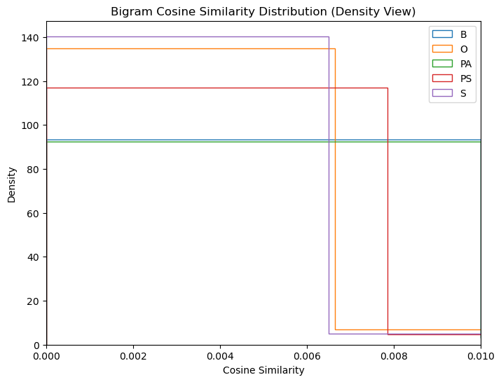

```python
# Module 8C5: Bigram Density Pot Between Groups

import numpy as np
import matplotlib.pyplot as plt

groups = sorted(df['school_type'].unique())

plt.figure(figsize=(8,6))

for g in groups:
    idx = df['school_type'] == g

    submat = cosine_matrix[idx, :].copy()

    # remove self comparisons
    row_indices = np.where(idx)[0]
    for i, row in enumerate(row_indices):
        submat[i, row] = np.nan

    vals = submat.flatten()
    vals = vals[~np.isnan(vals)]

    # Plot density
    plt.hist(vals, bins=100, density=True, histtype='step', label=g)

plt.xlabel("Cosine Similarity")
plt.ylabel("Density")
plt.title("Bigram Cosine Similarity Distribution (Density View)")
plt.legend()

# Zoom into meaningful range
plt.xlim(0, 0.01)

plt.show()
```

```python
# Module 8C6: Bigram Between School Types SNA Network

import networkx as nx

# Build network from bigram group similarity matrix
G_groups_bi = nx.from_pandas_adjacency(group_sim)

# Remove self-loops
G_groups_bi.remove_edges_from(nx.selfloop_edges(G_groups_bi))

print("Bigram group-level network:")
print("Nodes:", G_groups_bi.number_of_nodes())
print("Edges:", G_groups_bi.number_of_edges())
```

```
Bigram group-level network:
Nodes: 5
Edges: 10
```

## Institution-Level Network Structure

## Module 9: Social Network Analysis: Network Filtering

**Module 9A:** filters out weak relationships, keeping only the stronger ones. Each pair of institutions has a similarity score; the threshold allows only pairs with a similarity above that level to be kept as connections in the network. For the unigram network, the threshold is set at 0.05, which is close to the average similarity observed earlier. This means I am keeping relationships that are at least similar, while removing the weakest overlaps. The result is still a very dense network (616 course descriptions (nodes) connected in one component with 53,641 edges). This informs me that even after removing weak ties, many institutions still share a broad, common vocabulary. Schools tend to use similar general language, which keeps them widely connected. For the bigram network, I used a threshold of 0.07. The rationale is that bigrams are naturally more specific and produce lower similarity scores. By raising the threshold, I am focusing on phrase-level similarities. The result is a much sparser network (610 nodes and 5,214 edges) initially starts with two groups (2 connected components). This suggests that institutions are less uniformly similar without any threshold adjustment. The density values show how connected each network is relative to all possible connections. In the unigram network, a density of about 28% shows that the unigram network is somewhat dense, and most institutions share some level of vocabulary overlap. Since it is a fully connected structure, it indicates that language is widely shared across programs. In contrast, the bigram network with a density of about 2.8% is much sparser. This indicates that shared phrases are far less common.

**Module 9B** shows two network visualizations that highlight a clear structural difference between unigram and bigram similarity. The unigram network appears as a dense, highly interconnected mass, where nearly all institutions are linked through shared vocabulary, resulting in a tightly clustered structure with little visible separation. This suggests that general word usage is broadly consistent across institutions, making them appear similar. In contrast, the bigram network is more dispersed and less cohesive, with two visible gaps between groups of nodes. Smaller clusters and invisible isolated nodes begin to emerge, indicating that shared phrases are less common and more selective. This fragmentation suggests that bigram analysis captures more meaningful distinctions in how institutions describe their programs, revealing underlying differences that are not apparent at the unigram level.

**Module 9E** shows different color-coded network visualizations of how unigram and bigram networks change as the similarity threshold increases. The major difference in the module is that I cannot show a side-by-side comparison with networkx, and I am using matplotlib to show the visualizations. The key point here is that as the threshold levels increase substantially, one can visually see the components separating into distinct clusters. The disappearing nodes indicate increasing selectivity, which reveals which institutions are relatively more dissimilar to others.

**Module 9F** examines unigrams and bigrams across all course descriptions without any grouping variables. At the group level, each node represents an entire school type. When a threshold of 0.04 is applied to the group similarity network, a small number of edges emerge at the group level, indicating that only a few school-type pairings exceed the similarity threshold. However, the very limited number of connections reinforces that group-level similarity is weak and not structurally meaningful. This supports evidence found in Module 8. Differences between groups are weak and diffuse, and any overlap that does exist is insufficient to form an even modest cohesive, group-level network.

**Module 9G** visually shows that the filtered group-level network contains only a small number of connections between school types, with just three edges exceeding the threshold. The “Other” category serves as a weak bridge linking a few groups, while others, such as Professional Studies, remain completely isolated. The visualization reinforces earlier findings that linguistic similarity does not meaningfully aggregate by school type, and that any overlap in language is limited, inconsistent, and not organized into a clear network of relationships.

In **Module 9H**, I created a table showing that, even across lower thresholds (0.02–0.04), the group-level network loses structure as stricter similarity criteria are enforced. At the lowest thresholds (0.02 and 0.03), all 10 possible edges are present, meaning every school type is weakly connected to every other. It is essentially a fully connected network that is highly unstable. As the threshold increases to 0.035, the number of edges drops to 7, indicating that some of these already weak relationships no longer meet the cutoff. By 0.04, only 3 edges remain, showing that only a small subset of group pairings exhibits even modest similarity. This confirms that while school types may appear connected under very loose criteria, those connections are not strong or stable enough to form a meaningful or robust network structure.

```python
# Module 9A: Filter Networks by Similarity Threshold to Remove Weak Ties

def filter_graph(G, threshold):
    H = nx.Graph()

    for u, v, d in G.edges(data=True):
        w = d.get("weight", 0)
        if w > threshold:
            H.add_edge(u, v, weight=w)

    return H

def summarize_network(G, name):
    density = nx.density(G)
    components = nx.number_connected_components(G)

    print(f"\n{name} Network Summary:")
    print("Nodes:", G.number_of_nodes())
    print("Edges:", G.number_of_edges())
    print("Density:", round(density, 4))
    print("Connected Components:", components)

# Unigram Threshold
threshold_uni = 0.05
G_uni_filt = filter_graph(G_uni, threshold_uni)

summarize_network(G_uni_filt, f"Unigram (threshold={threshold_uni})")

# Bigram Threshold
threshold_bi = 0.07
G_bi_filt = filter_graph(G_bi, threshold_bi)

summarize_network(G_bi_filt, f"Bigram (threshold={threshold_bi})")
```

```
Unigram (threshold=0.05) Network Summary:
Nodes: 616
Edges: 53641
Density: 0.2832
Connected Components: 1

Bigram (threshold=0.07) Network Summary:
Nodes: 610
Edges: 5214
Density: 0.0281
Connected Components: 2
```

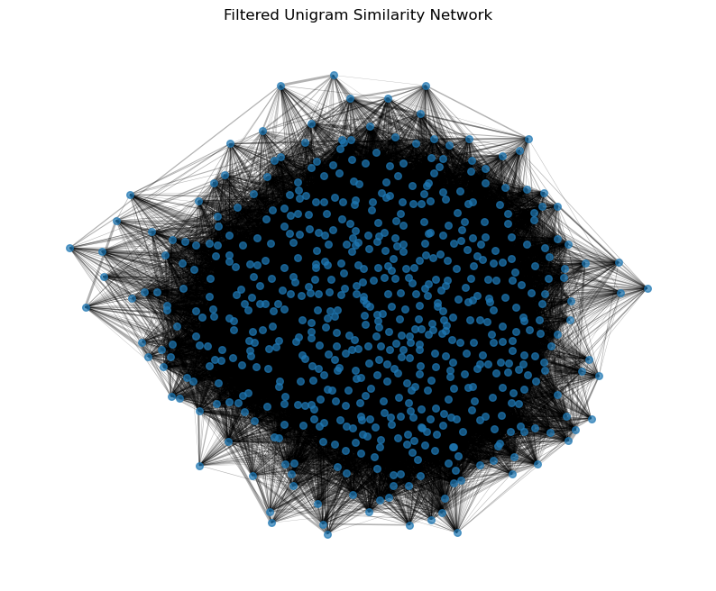

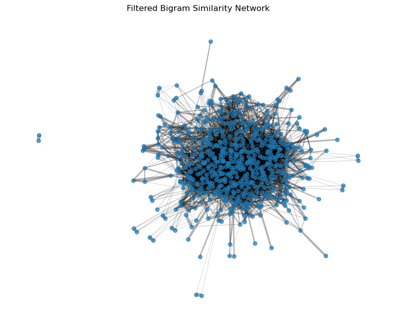

```python
# Module 9B: Network Visualization

import matplotlib.pyplot as plt

def plot_network(G, title):
    plt.figure(figsize=(10, 8))

    pos = nx.spring_layout(G, seed=32)

    edges = G.edges(data=True)
    weights = [d['weight'] for (_, _, d) in edges]

    nx.draw_networkx_nodes(G, pos, node_size=30, alpha=0.7)
    nx.draw_networkx_edges(G, pos, width=[w * 5 for w in weights], alpha=0.3)

    plt.title(title)
    plt.axis('off')
    plt.show()

plot_network(G_uni_filt, "Filtered Unigram Similarity Network")
plot_network(G_bi_filt, "Filtered Bigram Similarity Network")
```

```python
# Module 9C: Network Visualization

import numpy as np
import networkx as nx

def find_break_threshold(G, thresholds):
    for t in thresholds:
        H = filter_graph(G, t)
        comps = nx.number_connected_components(H)

        if comps > 1:
            return t, comps

    return None, 1  # never breaks

# Create fine-grained thresholds
thresholds = np.linspace(0, 0.2, 100)

# Run for both networks
t_uni, comps_uni = find_break_threshold(G_uni, thresholds)
t_bi, comps_bi = find_break_threshold(G_bi, thresholds)

print("Unigram breaks at:", t_uni, "→ components:", comps_uni)
print("Bigram breaks at:", t_bi, "→ components:", comps_bi)
```

```
Unigram breaks at: 0.1494949494949495 → components: 2
Bigram breaks at: 0.06060606060606061 → components: 2
```

```python
# Module 9D: Network Tabular Thresholds

thresholds = [0.05, 0.1, 0.1495, 0.2, 0.4]

results = []

for t in thresholds:
    G_u = filter_graph(G_uni, t)
    G_b = filter_graph(G_bi, t)

    results.append({
        "threshold": t,

        # Unigram metrics
        "uni_nodes": G_u.number_of_nodes(),
        "uni_edges": G_u.number_of_edges(),
        "uni_components": nx.number_connected_components(G_u),

        # Bigram metrics
        "bi_nodes": G_b.number_of_nodes(),
        "bi_edges": G_b.number_of_edges(),
        "bi_components": nx.number_connected_components(G_b)
    })

pd.DataFrame(results)
```

|  | threshold | uni_nodes | uni_edges | uni_components | bi_nodes | bi_edges | bi_components |
| --- | --- | --- | --- | --- | --- | --- | --- |
| 0 | 0.0500 | 616 | 53641 | 1 | 610 | 6694 | 1 |
| 1 | 0.1000 | 616 | 19922 | 1 | 610 | 3646 | 6 |
| 2 | 0.1495 | 616 | 8300 | 2 | 608 | 2049 | 26 |
| 3 | 0.2000 | 597 | 3923 | 7 | 573 | 1144 | 38 |
| 4 | 0.4000 | 292 | 317 | 68 | 278 | 193 | 103 |

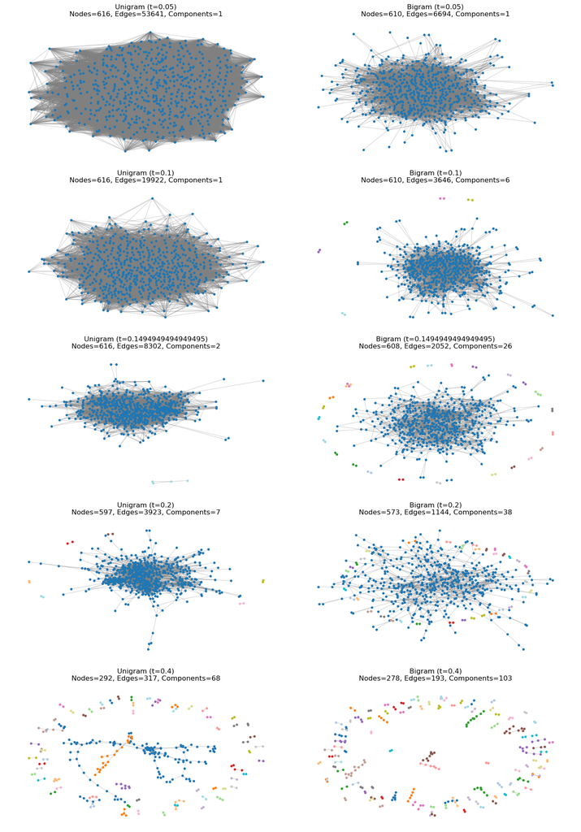

```python
# Module 9E: Network Visualization Thresholds

import matplotlib.pyplot as plt
import networkx as nx

thresholds = [0.05, 0.1, 0.1494949494949495, 0.2, 0.4]

fig, axes = plt.subplots(len(thresholds), 2, figsize=(14, 4 * len(thresholds)))

for i, t in enumerate(thresholds):

    # Filter networks
    G_uni_f = filter_graph(G_uni, t)
    G_bi_f = filter_graph(G_bi, t)

    # Layouts
    pos_uni = nx.spring_layout(G_uni_f, seed=42)
    pos_bi = nx.spring_layout(G_bi_f, seed=42)

    # Function to color components
    def draw_colored_graph(G, pos, ax, title):
        components = list(nx.connected_components(G))
        cmap = plt.cm.get_cmap('tab20', len(components))

        for j, comp in enumerate(components):
            nx.draw_networkx_nodes(
                G,
                pos,
                nodelist=list(comp),
                node_size=10,
                node_color=[cmap(j)],
                ax=ax
            )

        nx.draw_networkx_edges(G, pos, edge_color="gray", alpha=0.3, ax=ax)

        ax.set_title(title)
        ax.axis('off')

    # Unigram plot
    draw_colored_graph(
        G_uni_f,
        pos_uni,
        axes[i, 0],
        f"Unigram (t={t})\nNodes={G_uni_f.number_of_nodes()}, Edges={G_uni_f.number_of_edges()}, Components={nx.number_connected_components(G_uni_f)}"
    )

    # Bigram plot
    draw_colored_graph(
        G_bi_f,
        pos_bi,
        axes[i, 1],
        f"Bigram (t={t})\nNodes={G_bi_f.number_of_nodes()}, Edges={G_bi_f.number_of_edges()}, Components={nx.number_connected_components(G_bi_f)}"
    )

plt.tight_layout()
plt.show()
```

```python
# Module 9F: Build Group-Level Network Edges

G_groups_uni = nx.from_pandas_adjacency(group_sim_uni)

# Remove self-loops (diagonal)
G_groups_uni.remove_edges_from(nx.selfloop_edges(G_groups_uni))

def filter_graph(G, threshold):
    H = nx.Graph()
    H.add_nodes_from(G.nodes(data=True))

    for u, v, d in G.edges(data=True):
        if d["weight"] > threshold:
            H.add_edge(u, v, weight=d["weight"])

    return H

threshold = 0.04  # based on your group similarity range

G_groups_filt = filter_graph(G_groups_uni, threshold)

print("Filtered group network edges:", G_groups_filt.number_of_edges())
```

```
Filtered group network edges: 3
```

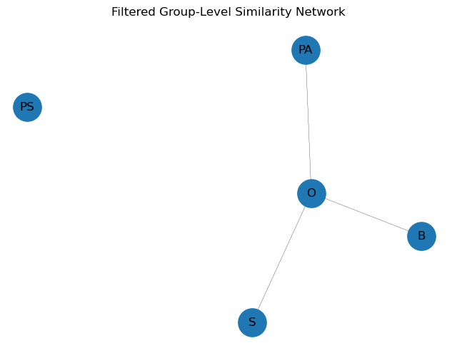

```python
# Module 9G: Plot Group-Level Network

plt.figure(figsize=(8, 6))

pos = nx.spring_layout(G_groups_filt, seed=42)

nx.draw_networkx_nodes(G_groups_filt, pos, node_size=800)
nx.draw_networkx_labels(G_groups_filt, pos)

edges = G_groups_filt.edges(data=True)
weights = [d['weight'] for (_, _, d) in edges]

nx.draw_networkx_edges(G_groups_filt, pos, width=[w * 5 for w in weights])

plt.title("Filtered Group-Level Similarity Network")
plt.axis('off')
plt.show()
```

```python
# Module 9H: Group-Level Network Threshold Levels

for t in [0.02, 0.03, 0.035, 0.04]:
    G_temp = filter_graph(G_groups_uni, t)
    print(f"Threshold {t}: {G_temp.number_of_edges()} edges")
```

```
Threshold 0.02: 10 edges
Threshold 0.03: 10 edges
Threshold 0.035: 7 edges
Threshold 0.04: 3 edges
```

```python
# Module 9I: Group-Level Network Threshold Levels

print(group_sim_uni.round(4))
```

```
        PA       B       S      PS       O
PA  0.0435  0.0397  0.0373  0.0334  0.0410
B   0.0397  0.0394  0.0367  0.0340  0.0402
S   0.0373  0.0367  0.0390  0.0340  0.0413
PS  0.0334  0.0340  0.0340  0.0374  0.0373
O   0.0410  0.0402  0.0413  0.0373  0.0525
```

## Module 10: Social Network Analysis: Centrality Measures

**Modules 10A-E** These results compare how the same nodes behave in two different network constructions—unigram (word-level similarity) versus bigram (phrase-level similarity)—across four centrality measures. The pattern is consistent and informative.

In the unigram network, centrality values are uniformly higher across all measures. Degree centrality ranges roughly from 0.56–0.63, indicating that these nodes are connected to a large proportion of the network. In other words, high and uniform degree centrality in the unigram network indicates that most course descriptions are directly connected to a large share of other descriptions, reflecting extensive vocabulary overlap. This suggests a highly saturated linguistic environment in which programs rely on a common set of terms, resulting in dense local connectivity and limited differentiation.

Closeness values are also relatively high, 0.687–0.730, meaning these nodes sit near the center of the network and can “reach” others quickly. In other words, High and uniform closeness centrality in the unigram network indicates that course descriptions occupy a tightly integrated linguistic space, where all programs are similarly proximate to one another.

Betweenness is low 0.004–0.0.006, but nonzero, suggesting some nodes act as minor bridges, while eigenvector centrality is modest but consistent, 0.073-0.084, indicating influence within a broadly dense structure. This reflects a highly interconnected network driven by general word overlap, in which many courses appear similar at the surface. In other words, in the unigram network, betweenness centrality is limited and relatively homogeneous, reflecting the absence of structurally distinct bridging nodes. Because most course descriptions share a common vocabulary, the network contains multiple redundant pathways, reducing the importance of any single node as an intermediary.

Eigenvector centrality values are relatively modest but tightly clustered (0.073–0.084), indicating that influence is evenly distributed across nodes. Eigenvector centrality captures whether a node is connected to other highly connected and influential nodes. It reflects embeddedness within the network's core structure, rather than connectivity. Because most course descriptions are connected to many others that are themselves highly connected, no single node emerges as structurally dominant. Instead, influence is diffuse, reinforcing the interpretation of a flat, non-hierarchical network built on a shared and standardized vocabulary.

Taken together, the results show that the unigram network captures broad, diffuse similarity, making many nodes appear central, while the bigram network captures more specific, meaningful connections, highlighting fewer but more structurally important nodes. In practical terms, unigram centrality identifies generally typical or commonly described courses, whereas bigram centrality isolates courses that are more distinctive or structurally influential in how ideas are expressed across the dataset.

**Module 10G** This network visualization shows a very dense and highly connected unigram network, where nearly every node is linked to many others. The large, tightly packed central cluster indicates that most courses share substantial overlap in vocabulary at the single-word level. Because degree centrality is driving node size here, the relatively uniform and consistently large nodes suggest that many nodes have similarly high connectivity, rather than a few dominant hubs.

The “hairball” appearance, where edges heavily overlap and the center is visually saturated, signals that the network lacks clear structural separation. In practical terms, this means the unigram approach captures broad, generalized similarity, making most courses appear closely related even when their deeper content differs. The few peripheral nodes represent courses with slightly less vocabulary overlap, but they are still connected to the main cluster, reinforcing that the network is essentially one large component.

Overall, this graph confirms that unigram similarity produces a high-density, low-discrimination network in which differences between nodes are muted. It highlights common language across course descriptions rather than distinct thematic or conceptual groupings, which is why the structure appears visually compressed and difficult to interpret beyond the general conclusion of widespread similarity.

This bigram network is noticeably sparser and more structured than the unigram “hairball,” and that difference is the main story.

The central cluster still exists, but it is smaller, looser, and less saturated, indicating that far fewer nodes are strongly connected. Because bigrams require shared phrases rather than individual words, most courses no longer appear universally similar. As a result, connections are more selective, and the network begins to show meaningful variation in connectivity. The variation in node size (degree centrality) is more visible here, suggesting that a smaller set of nodes functions as more prominent hubs compared to the relatively uniform unigram network.

You can also see peripheral nodes and small isolated components, including a few nodes that are completely disconnected from the main cluster. These represent courses that do not share common phrasing with others, highlighting distinct or specialized language. The longer, thinner edge patterns extending outward from the core indicate weaker or more limited connections. This reinforces the idea that similarity is no longer widespread.

Overall, this visualization shows that the bigram approach produces a lower-density, higher-discrimination network. Instead of capturing broad, generic overlap, it isolates more specific linguistic relationships, allowing structural features, like hubs, bridges, and isolated nodes, to emerge more clearly. This makes the bigram network more useful for identifying meaningful differences and clusters in how course content is described.

```python
# Module 10A: Degree Centrality

deg_uni = nx.degree_centrality(G_uni_filt)

# Build table
deg_uni_df = (
    pd.Series(deg_uni)
    .sort_values(ascending=False)
    .head(5)
    .reset_index()
)

deg_uni_df.columns = ["node_id", "degree_centrality"]
deg_uni_df["Unigram degree_centrality"] = deg_uni_df["degree_centrality"].round(3)

# Display
from IPython.display import display

display(
    deg_uni_df.style
    .set_properties(**{
        'text-align': 'left'
    })
    .set_table_styles([
        {'selector': 'th', 'props': [('text-align', 'left')]}
    ])
)
```

|  | node_id | degree_centrality | Unigram degree_centrality |
| --- | --- | --- | --- |
| 0 | 33 | 0.630894 | 0.631000 |
| 1 | 146 | 0.608130 | 0.608000 |
| 2 | 466 | 0.603252 | 0.603000 |
| 3 | 148 | 0.583740 | 0.584000 |
| 4 | 144 | 0.583740 | 0.584000 |

```python
# Module 10B: Degree Centrality (Bigram)

# Bigram degree centrality
deg_bi = nx.degree_centrality(G_bi_filt)

# Build table - top 5 by centrality
deg_bi_df = (
    pd.Series(deg_bi)
    .sort_values(ascending=False)
    .head(5)
    .reset_index()
)

deg_bi_df.columns = ["node_id", "degree_centrality"]
deg_bi_df["Bigram degree_centrality"] = deg_bi_df["degree_centrality"].round(3)

# Display
from IPython.display import display

display(
    deg_bi_df.style
    .set_properties(**{'text-align': 'left'})
    .set_table_styles([
        {'selector': 'th', 'props': [('text-align', 'left')]}
    ])
)
```

|  | node_id | degree_centrality | Bigram degree_centrality |
| --- | --- | --- | --- |
| 0 | 39 | 0.091954 | 0.092000 |
| 1 | 510 | 0.088670 | 0.089000 |
| 2 | 552 | 0.082102 | 0.082000 |
| 3 | 25 | 0.078818 | 0.079000 |
| 4 | 561 | 0.077176 | 0.077000 |

```python
# Module 10C: Betweenness Centrality

# Betweenness Centrality
bet_uni = nx.betweenness_centrality(G_uni_filt)
bet_bi = nx.betweenness_centrality(G_bi_filt)

print("Unigram Top Betweenness:")
print(pd.Series(bet_uni).sort_values(ascending=False).head(10))

print("\nBigram Top Betweenness:")
print(pd.Series(bet_bi).sort_values(ascending=False).head(10))
```

```
Unigram Top Betweenness:
466    0.005992
33     0.005709
146    0.005248
144    0.004880
148    0.004880
610    0.004186
482    0.004087
145    0.004005
141    0.004005
541    0.003973
dtype: float64

Bigram Top Betweenness:
39     0.023778
510    0.022676
103    0.016276
404    0.016060
482    0.016050
143    0.015875
25     0.015869
582    0.015669
581    0.014700
57     0.014524
dtype: float64
```

```python
# Module 10D: Closeness Centrality

# Closeness Centrality
close_uni = nx.closeness_centrality(G_uni_filt)
close_bi = nx.closeness_centrality(G_bi_filt)

print("Unigram Top Closeness:")
print(pd.Series(close_uni).sort_values(ascending=False).head(10))

print("\nBigram Top Closeness:")
print(pd.Series(close_bi).sort_values(ascending=False).head(10))
```

```
Unigram Top Closeness:
33     0.730404
146    0.718458
466    0.715949
148    0.706085
144    0.706085
147    0.694131
142    0.694131
141    0.687919
145    0.687919
57     0.687151
dtype: float64

Bigram Top Closeness:
510    0.447159
404    0.442580
39     0.441933
582    0.439685
277    0.435257
103    0.431839
124    0.430916
545    0.429998
244    0.429387
552    0.429083
dtype: float64
```

```python
# Module 10E: Eigenvector Centrality

# Eigenvector Centrality
eig_uni = nx.eigenvector_centrality(G_uni_filt, max_iter=1000)
eig_bi = nx.eigenvector_centrality(G_bi_filt, max_iter=1000)

print("Unigram Top Eigenvector:")
print(pd.Series(eig_uni).sort_values(ascending=False).head(10))

print("\nBigram Top Eigenvector:")
print(pd.Series(eig_bi).sort_values(ascending=False).head(10))
```

```
Unigram Top Eigenvector:
33     0.083760
146    0.080194
466    0.077764
144    0.077292
148    0.077292
147    0.076755
142    0.076755
57     0.074415
141    0.073373
145    0.073373
dtype: float64

Bigram Top Eigenvector:
244    0.166646
552    0.166568
277    0.154885
25     0.147582
39     0.146839
561    0.145507
356    0.142952
365    0.142539
346    0.138628
48     0.136828
dtype: float64
```

```python
# Module 10F: Combine Centrality Measures

centrality_df = pd.DataFrame({
    "Unigram degree": pd.Series(deg_uni),
    "Unigram betweenness": pd.Series(bet_uni),
    "Unigram closeness": pd.Series(close_uni),
    "Unigram eigenvector": pd.Series(eig_uni),

    "Bigram degree": pd.Series(deg_bi),
    "Bigram betweenness": pd.Series(bet_bi),
    "Bigram closeness": pd.Series(close_bi),
    "Bigram eigenvector": pd.Series(eig_bi)
})

centrality_df.head()
```

|  | Unigram degree | Unigram betweenness | Unigram closeness | Unigram eigenvector | Bigram degree | Bigram betweenness | Bigram closeness | Bigram eigenvector |
| --- | --- | --- | --- | --- | --- | --- | --- | --- |
| 0 | 0.211382 | 0.000594 | 0.559091 | 0.027591 | 0.014778 | 0.000528 | 0.347705 | 0.014280 |
| 1 | 0.320325 | 0.001065 | 0.595353 | 0.045608 | 0.052545 | 0.003602 | 0.411849 | 0.084140 |
| 2 | 0.295935 | 0.001041 | 0.586832 | 0.040267 | 0.037767 | 0.002708 | 0.387825 | 0.041068 |
| 3 | 0.330081 | 0.001226 | 0.598832 | 0.045876 | 0.042693 | 0.008428 | 0.390831 | 0.034457 |
| 4 | 0.422764 | 0.002442 | 0.634021 | 0.055938 | 0.021346 | 0.003655 | 0.356096 | 0.025908 |

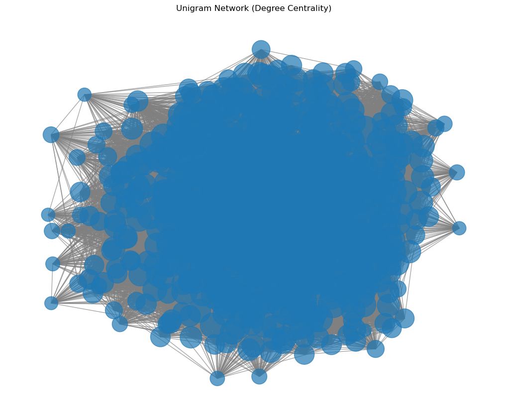

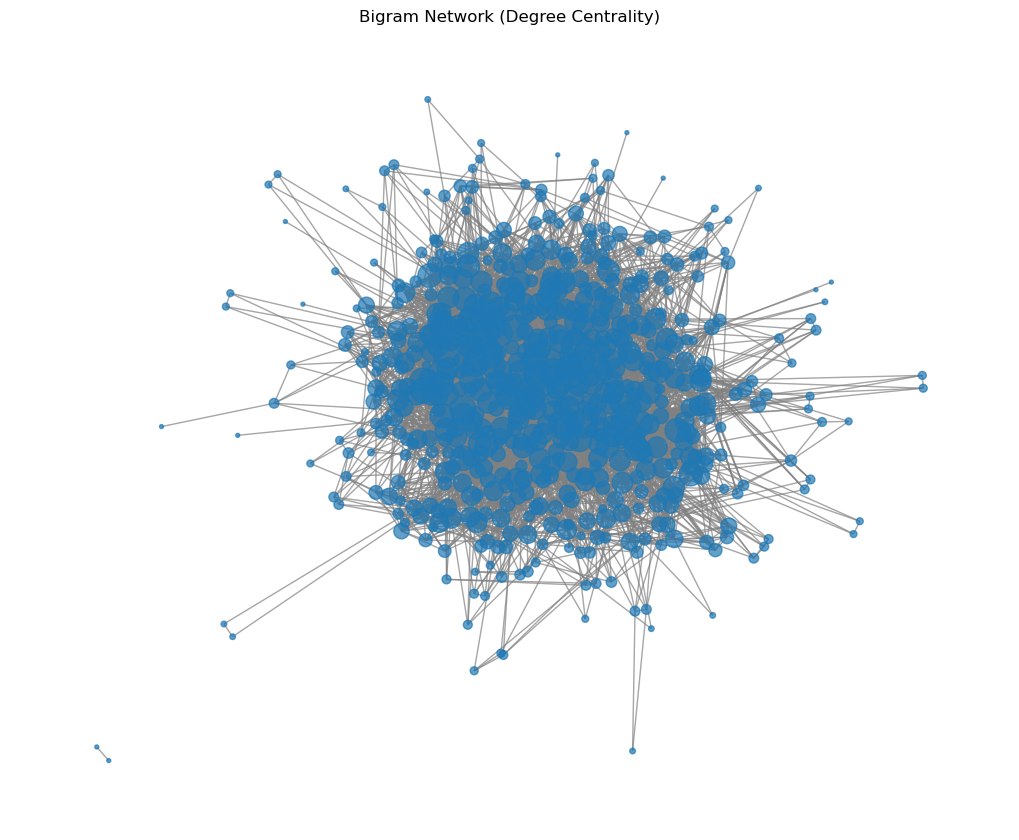

```python
# Module 10G: Visualize Central Nodes

def plot_centrality(G, centrality, title):
    plt.figure(figsize=(10,8))

    pos = nx.spring_layout(G, seed=42)

    node_sizes = [v * 5000 for v in centrality.values()]

    nx.draw(G, pos,
            node_size=node_sizes,
            edge_color='gray',
            with_labels=False,
            alpha=0.7)

    plt.title(title)
    plt.axis('off')
    plt.show()

plot_centrality(G_uni_filt, deg_uni, "Unigram Network (Degree Centrality)")
plot_centrality(G_bi_filt, deg_bi, "Bigram Network (Degree Centrality)")
```

## Module 11: Social Network Analysis: Community Detection

Community detection at this point in the research important. It is a way of identifying natural groupings within a network by looking at which items are more closely connected to each other than to the rest. Instead of predefining categories, it allows patterns to emerge. A simple way to understand the context in which I am using community detection is through a hypothetical real-world scenario. Imagine several faculty and staff members from different universities attending a conference on marketing their programs. Over lunch, conversations unfold surrounding nonprofit management, different groups naturally form. At one table, one group discusses fundraising strategies and grant writing, sharing ideas about donor engagement and resource development. At another table, a group is focused on financial management, talking about budgeting, financial reporting, and accountability. A third group is engaged in conversations about leadership and governance, discussing board structures and organizational roles. Without labels, as oe walks by the tables, one can hear the group's shared interests and priorities.

Community detection mathematically examines how nodes are connected by similarity and identifies clusters in which connections are stronger within the group than outside it. Instead of seeing a single, tangled network, community detection reveals how content naturally organizes into meaningful themes. This analysis helps uncover how nonprofit management courses cluster around topics. It also highlights differences in how similarity is measured. Unigram-based networks tend to group many courses into a few broad, overlapping clusters, while bigram-based networks reveal more distinct and specialized communities.

**Module 11A** results highlight a structural difference between the unigram and bigram networks. The unigram network produces only 2 communities, indicating that most nodes are grouped into a small number of large clusters. This reflects the dense, highly interconnected nature of the unigram network, where widespread word overlap causes many courses to appear similar, suggesting shared language rather than distinct thematic boundaries. In contrast, the bigram network yields 14 communities, revealing a much more fragmented and differentiated structure. Because bigrams require shared phrases rather than individual words, connections are more selective, leading to smaller, more cohesive clusters. This higher number of communities indicates that the network contains multiple distinct subgroups, each characterized by more specific and meaningful patterns of language use.

Another key difference is the role of peripheral nodes. In the unigram network, almost all nodes are absorbed into the central mass, reinforcing the idea of universal similarity. In the bigram network, however, peripheral and isolated nodes are common, signaling courses with unique or less shared phrasing. This contributes to the higher number of communities and clearer boundaries. Overall, the visualizations confirm the earlier quantitative result: the unigram network produces few, weakly separated communities within a highly dense structure, while the bigram network produces many, more distinct communities within a sparser and more interpretable structure.

The key takeaway is not just the presence of more communities, but that those communities shift from how they are dominant to how they are dispersed. Unlike the unigram network, which concentrates most nodes into a few large, overlapping groups, the bigram network distributes nodes across a wider range of communities with clearer thematic boundaries. At the same time, it introduces over-fragmentation at the lower end, where conceptually similar material is split into multiple small clusters. This is an interesting illustration of the bigram trade-off. My example provides greater thematic precision but also produces excessively granular segmentation.

```python
# Module 11A: Community Detection

import networkx as nx
from networkx.algorithms.community import greedy_modularity_communities

def filter_graph(G, threshold):
    H = nx.Graph()
    H.add_nodes_from(G.nodes(data=True))

    for u, v, d in G.edges(data=True):
        w = d.get("weight", 0)
        if w > threshold:
            H.add_edge(u, v, weight=w)

    return H

# Build unigram graph
G_uni = nx.from_pandas_adjacency(cosine_df)
G_uni.remove_edges_from(nx.selfloop_edges(G_uni))

# Filter
G_uni_filt = filter_graph(G_uni, threshold_uni)

# Build bigram graph
G_bi = nx.from_pandas_adjacency(cosine_df_bg)
G_bi.remove_edges_from(nx.selfloop_edges(G_bi))

# Filter
G_bi_filt = filter_graph(G_bi, threshold_bi)

# Community detection
communities_uni = greedy_modularity_communities(G_uni_filt)
communities_bi = greedy_modularity_communities(G_bi_filt)

# Convert to node to community mapping
partition_uni = {node: i for i, comm in enumerate(communities_uni) for node in comm}
partition_bi = {node: i for i, comm in enumerate(communities_bi) for node in comm}

print("Unigram communities:", len(communities_uni))
print("Bigram communities:", len(communities_bi))
```

```
Unigram communities: 2
Bigram communities: 14
```

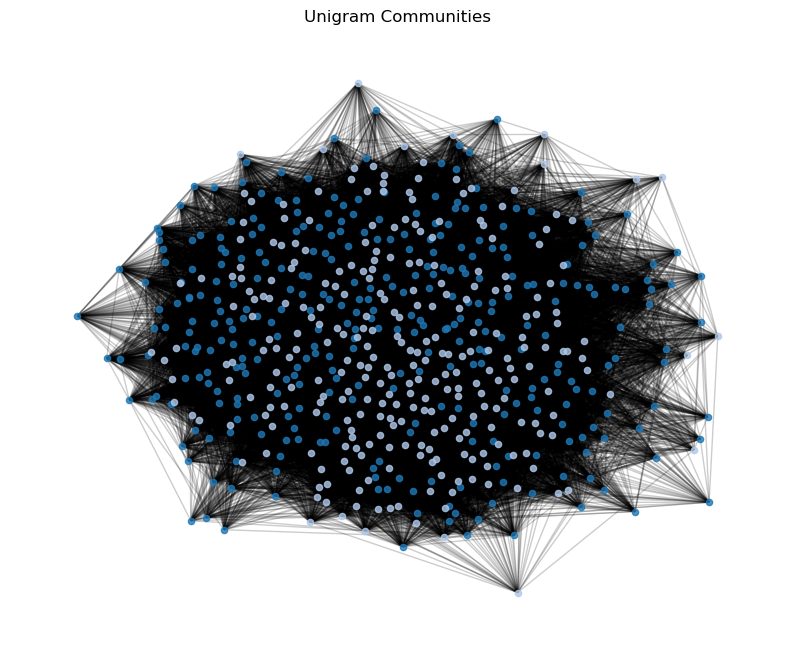

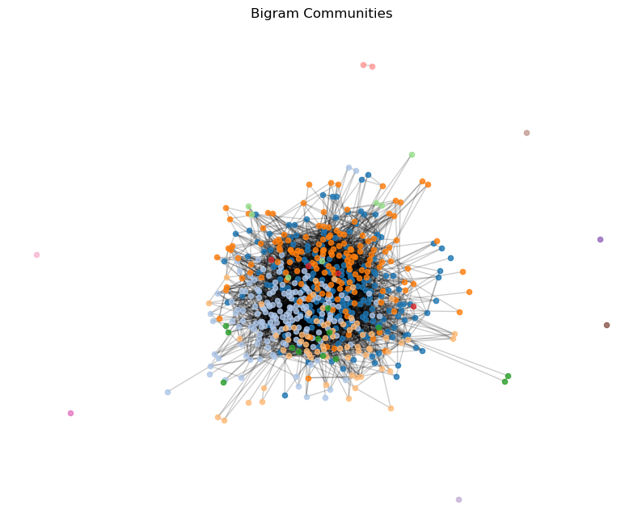

```python
# Module 11B: Visualize Communities

import matplotlib.pyplot as plt

def plot_communities(G, partition, title):
    plt.figure(figsize=(10, 8))

    # Layout
    pos = nx.spring_layout(G, seed=42)

    # Get unique communities
    communities = set(partition.values())

    # Color map
    colors = plt.cm.tab20(range(len(communities)))

    # Draw nodes by community
    for comm, color in zip(communities, colors):
        nodes = [node for node in partition if partition[node] == comm]

        nx.draw_networkx_nodes(
            G, pos,
            nodelist=nodes,
            node_size=20,
            node_color=[color],
            label=f"Community {comm}",
            alpha=0.8
        )

    # Draw edges
    nx.draw_networkx_edges(G, pos, alpha=0.2)

    plt.title(title)
    plt.axis('off')
    plt.show()

plot_communities(G_uni_filt, partition_uni, "Unigram Communities")
plot_communities(G_bi_filt, partition_bi, "Bigram Communities")
```

```python
# Module 11C: Community Themes (Unigram)

from sklearn.feature_extraction.text import TfidfVectorizer
import numpy as np

# Rebuild text
docs = df['tokens'].apply(lambda x: " ".join(x))

# Vectorize
vectorizer = TfidfVectorizer(min_df=2)
tfidf_matrix = vectorizer.fit_transform(docs)

terms = np.array(vectorizer.get_feature_names_out())

# Build community to node mapping
comm_groups = {}
for node, comm in partition_uni.items():
    comm_groups.setdefault(comm, []).append(node)

# Extract top terms per community
community_terms = {}

for comm, nodes in comm_groups.items():
    submatrix = tfidf_matrix[nodes]

    # average TF-IDF scores
    mean_tfidf = submatrix.mean(axis=0).A1

    top_terms = terms[np.argsort(mean_tfidf)[-10:][::-1]]
    community_terms[comm] = top_terms

# Display
for comm, terms_list in community_terms.items():
    print(f"\nCommunity {comm}:")
    print(", ".join(terms_list))
```

```
Community 0:
nonprofit, course, leadership, organizations, students, social, public, examines, research, ethical

Community 1:
financial, nonprofit, public, management, covers, organizations, focuses, budgeting, practices, fundraising
```

```python
# Module 11D: Community Themes (Bigram)

vectorizer_bg = TfidfVectorizer(ngram_range=(2,2), min_df=2)
tfidf_matrix_bg = vectorizer_bg.fit_transform(docs)

terms_bg = np.array(vectorizer_bg.get_feature_names_out())

# Build mapping
comm_groups_bi = {}
for node, comm in partition_bi.items():
    comm_groups_bi.setdefault(comm, []).append(node)

community_terms_bi = {}

for comm, nodes in comm_groups_bi.items():
    submatrix = tfidf_matrix_bg[nodes]
    mean_tfidf = submatrix.mean(axis=0).A1

    top_terms = terms_bg[np.argsort(mean_tfidf)[-10:][::-1]]
    community_terms_bi[comm] = top_terms

# Display
for comm, terms_list in community_terms_bi.items():
    print(f"\nCommunity {comm}:")
    print(", ".join(terms_list))
```

```
Community 0:
nonprofit sector, nonprofit organizations, strategic planning, nonprofit organization, grant writing, social change, fundraising strategies, resource development, social impact, grant proposals

Community 1:
nonprofit organizations, public sector, human resource, human resources, case studies, sector organizations, resource management, ethical issues, course focuses, examines ethical

Community 2:
nonprofit organizations, best practices, financial management, nonprofit management, social media, students opportunity, financial planning, financial reporting, principles practices, financial statements

Community 3:
public administration, research methods, public policy, nonprofit sectors, introduces students, applied project, nonprofit administration, comprehensive project, administration principles, development implementation

Community 4:
analytical tools, business environment, decision making, global economy, design thinking, graduate level, become familiar, nonprofit organizational, rapidly changing, evaluating nonprofit

Community 5:
reflective work, strengths weaknesses, students analyze, course students, media plan, developed course, research skills, essential emergence, emergence evolution, evolution existence

Community 6:
course covers, models leadership, within organization, leadership styles, organizational behavior, various leadership, business models, modern organizations, teams organizations, competitive advantage

Community 7:
recognition value, marketing programs, approaches particular, programs coursework, coursework emphasizes, value services, focuses include, emphasizes skills, development skills, discusses marketing

Community 8:
writing winning, finances nonprofit, financial decisions, financial controls, financial concepts, financial capital, financial analysis, financial accounting, financial accountability, finances human

Community 9:
writing winning, finances nonprofit, financial decisions, financial controls, financial concepts, financial capital, financial analysis, financial accounting, financial accountability, finances human

Community 10:
writing winning, finances nonprofit, financial decisions, financial controls, financial concepts, financial capital, financial analysis, financial accounting, financial accountability, finances human

Community 11:
practices nonprofit, nonprofit organizations, finances nonprofit, financial controls, financial concepts, financial capital, financial analysis, financial accounting, financial accountability, finances human

Community 12:
writing winning, finances nonprofit, financial decisions, financial controls, financial concepts, financial capital, financial analysis, financial accounting, financial accountability, finances human

Community 13:
writing winning, finances nonprofit, financial decisions, financial controls, financial concepts, financial capital, financial analysis, financial accounting, financial accountability, finances human
```

```python
# Module 11E: Community Themes Unigram Summary Table

summary_rows = []

for comm, nodes in comm_groups.items():
    summary_rows.append({
        "community": comm,
        "size": len(nodes),
        "top_terms": ", ".join(community_terms[comm][:5])
    })

comm_summary_df = pd.DataFrame(summary_rows).sort_values("size", ascending=False)

from IPython.display import display

display(
    comm_summary_df.style
    .set_properties(**{
        'text-align': 'left'
    })
    .set_table_styles([
        {'selector': 'th', 'props': [('text-align', 'left')]}
    ])
)
```

|  | community | size | top_terms |
| --- | --- | --- | --- |
| 0 | 0 | 331 | nonprofit, course, leadership, organizations, students |
| 1 | 1 | 285 | financial, nonprofit, public, management, covers |

```python
# Module 11F: Community Themes Bigram Summary Table

# Build summary rows
summary_rows_bi = []

for comm, nodes in comm_groups_bi.items():
    summary_rows_bi.append({
        "community": comm,
        "size": len(nodes),
        "top_terms": ", ".join(community_terms_bi[comm][:5])
    })

# Create DataFrame
comm_summary_bi_df = pd.DataFrame(summary_rows_bi).sort_values("size", ascending=False)

# Display (left-aligned)
from IPython.display import display

display(
    comm_summary_bi_df.style
    .set_properties(**{
        'text-align': 'left'
    })
    .set_table_styles([
        {'selector': 'th', 'props': [('text-align', 'left')]}
    ])
)
```

|  | community | size | top_terms |
| --- | --- | --- | --- |
| 0 | 0 | 188 | nonprofit sector, nonprofit organizations, strategic planning, nonprofit organization, grant writing |
| 1 | 1 | 175 | nonprofit organizations, public sector, human resource, human resources, case studies |
| 2 | 2 | 152 | nonprofit organizations, best practices, financial management, nonprofit management, social media |
| 3 | 3 | 69 | public administration, research methods, public policy, nonprofit sectors, introduces students |
| 4 | 4 | 13 | analytical tools, business environment, decision making, global economy, design thinking |
| 5 | 5 | 7 | reflective work, strengths weaknesses, students analyze, course students, media plan |
| 6 | 6 | 4 | course covers, models leadership, within organization, leadership styles, organizational behavior |
| 7 | 7 | 2 | recognition value, marketing programs, approaches particular, programs coursework, coursework emphasizes |
| 8 | 8 | 1 | writing winning, finances nonprofit, financial decisions, financial controls, financial concepts |
| 9 | 9 | 1 | writing winning, finances nonprofit, financial decisions, financial controls, financial concepts |
| 10 | 10 | 1 | writing winning, finances nonprofit, financial decisions, financial controls, financial concepts |
| 11 | 11 | 1 | practices nonprofit, nonprofit organizations, finances nonprofit, financial controls, financial concepts |
| 12 | 12 | 1 | writing winning, finances nonprofit, financial decisions, financial controls, financial concepts |
| 13 | 13 | 1 | writing winning, finances nonprofit, financial decisions, financial controls, financial concepts |

## References

Akerlof, G. A. 1970. The Market for "Lemons": Quality Uncertainty and the Market Mechanism. The Quarterly journal of economics. 84(3), 488–500, https://doi.org/10.2307/1879431

Amey, M. J. 1992. Using catalogues to track institutional viability and change. New directions for higher education. 1992(80), 23–36, https://doi.org/10.1002/he.36919928004

Brock, J. 2004. Public Management: Where Do We Go from Here? Or, What Do We Know and When Did We Know It? Journal of policy analysis and management. 23(3), 617–631, https://doi.org/10.1002/pam.20031.

Natural Language Toolkit. (n.d.). *Natural Language Toolkit*. https://www.nltk.org/

OpenAI. (2025). ChatGPT (GPT-5.3) [Large language model]. Used for coding assistance and text refinement. https://chat.openai.com/

Tsvetovat & Kouznetsov (2011). Social Network Analysis for Startups.

United States Bureau of Labor Statistics. (2025). Business Employment Dynamics, Nonprofit Sector Research Data 2018 to 2022. Retrieved October 5, 2025 from https://www.bls.gov/bdm/nonprofits/nonprofits.htm

United States Bureau of Labor Statistics. (2025b). Private industry nonprofit workers had the highest levels of formal education in 2022. Retrieved October 5, 2025 from https://www.bls.gov/opub/ted/2023/private-industry-nonprofit-workers-had-the-highest-levels-of-formal-education-in-2022.htm